# Final Code

Yael Yossefy, Lejing Li, Zihui Chen

2025-10-31

# Load in Data and Libraries

```r
standardized_terminology <- read.csv('standardized_terminology.csv')
medication_drug <- read.csv('medication_drug.csv')
medication_ingredient <- read.csv('medication_ingredient.csv')
patient <- read.csv('patient.csv')
patient_cohort <- read.csv('patient_cohort.csv')
procedure <- read.csv('procedure.csv')
oncology_treatment <- read.csv('oncology_treatment.csv')
claim_header <- read.csv("claim_header.csv")
tumor <- read.csv('tumor.csv')
encounter <- read.csv('encounter.csv')
member_enrollment <- read.csv('member_enrollment.csv')
diagnosis <- read.csv('diagnosis.csv')
lab_result <- read.csv('lab_result.csv')
vitals_signs <- read.csv('vitals_signs.csv')
chemo_lines <- read.csv('chemo_lines.csv')
```

```r
library(dplyr)
library(sqldf)
library(gtsummary)
library(tidyverse)
```

```r
library(ggplot2)
library(lubridate)
library(janitor)
library(survival)
library(survminer)
```

## Converting necessary dates

```r
tumor$diagnosis_date <- as.Date(as.character(tumor$diagnosis_date), "%Y%m%d")
tumor$observation_date <- as.Date(as.character(tumor$observation_date), "%Y%m%d")
medication_ingredient$start_date <- as.Date(as.character(medication_ingredient$start_date), "%Y%m%d")
procedure$date <- as.Date(as.character(procedure$date), "%Y%m%d")
member_enrollment$effective_date <- as.Date(as.character(member_enrollment$effective_date), "%Y%m%d")
member_enrollment$termination_date <- as.Date(as.character(member_enrollment$termination_date), "%Y%m%d")
encounter$start_date <- as.Date(as.character(encounter$start_date), "%Y%m%d")
encounter$end_date <- as.Date(as.character(encounter$end_date), "%Y%m%d")
diagnosis$date <- as.Date(as.character(diagnosis$date), "%Y%m%d")
lab_result$date <- as.Date(as.character(lab_result$date), "%Y%m%d")
vitals_signs$date <- as.Date(as.character(vitals_signs$date), "%Y%m%d")
chemo_lines$start_date <- as.Date(as.character(chemo_lines$start_date), "%Y%m%d")
```

# Cohort Creation

## On Pembrolizumab

```r
# Search for pembrolizumab in standardized terminology table
filtered_pembrolizumab <- standardized_terminology[grepl("pembrolizumab", standardized_terminology$code_description, ignore.case = TRUE), ]

# Filter Medication Ingredient Table using pembrolizumab codes
pembrolizumab_medication_ingredient <- medication_ingredient |>
  filter(code %in% filtered_pembrolizumab$code)

# Filter Procedure Table using pembrolizumab codes
pembrolizumab_procedure <- procedure |>
  filter(code %in% filtered_pembrolizumab$code)
```

When you filter for the pembrolizumab code (1547545) in the medication ingredient table, you get a cohort of 536 distinct patients. When you filter for pemrolizumab code (J9271) in the procedure table, you get a cohort of 493 distinct patients on pembrolizumab. Among the 43 patients with pembrolizumab records only in medication_ingredient.csv, all of them had chemotherapy record and had their pembrolizumab use date within ±7 days of a system-recorded chemotherapy line. This temporal overlap strongly suggests that pembrolizumab was part of the chemotherapy regimen, despite the absence of a corresponding J-code (J9271) in procedure.csv. So we will use the cohort including 536 patients.

```r
# Filter patient table to only patients on pembrolizumab medication ingredient
patient_cohort <- patient |>
  filter(patient_id %in% pembrolizumab_medication_ingredient$patient_id)


# Filter the medication_ingredient table to only patients who are on pembrolizumab (but include all their rows of medications)
medication_ingredient_cohort <- medication_ingredient |>
  filter(patient_id %in% patient_cohort$patient_id)
```

## Diagnosis Date

*Earliest Breast Cancer Diagnosis (For Each Patient)*

```r
# Find the codes associated for malignant Breast Cancer in Standardized Terminology Table

standardized_terminology_breast <- standardized_terminology[grepl("breast", standardized_terminology$code_description, ignore.case = TRUE), ] %>%
  filter(code_system %in% c("ICD-10-CM","ICD-9-CM","ICD-10-PCS"))

standardized_terminology_breast_cancer <- standardized_terminology_breast[
  grepl("malignant|carcinoma|Anaplastic large cell lymphoma", standardized_terminology_breast$code_description, ignore.case = TRUE),
]

standardized_terminology_breast_cancer2 <- standardized_terminology_breast_cancer[
  !grepl("secondary|history|screening|susceptibility|lobular", standardized_terminology_breast_cancer$code_description, ignore.case = TRUE),
]

diagnosis_BC <- diagnosis %>%
  filter(patient_id %in% pembrolizumab_medication_ingredient$patient_id,
         code %in% standardized_terminology_breast_cancer2$code)

diagnosis_BC_earliest <- diagnosis_BC %>%
  group_by(patient_id) %>%
  slice_min(order_by = date, with_ties = FALSE) %>%
  ungroup() %>%
  rename(BC_diagnosis_date = date)
```

## pembro_initiation

*Earliest Start Date Record of Pembro (For Each Patient)*

```r
# Step 1: Rename columns to have the same name for consistency
proc_df <- pembrolizumab_procedure %>%
  select(patient_id, date) %>%
  rename(event_date = date)

med_df <- pembrolizumab_medication_ingredient %>%
  select(patient_id, start_date) %>%
  rename(event_date = start_date)

# Step 2: Combine both data frames
combined_df <- bind_rows(proc_df, med_df)

# Step 3: Order by patient_id and event_date
combined_df <- combined_df %>%
  arrange(patient_id, event_date)

# Step 4: Assign a sequential date index per patient
combined_df <- combined_df %>%
  group_by(patient_id) %>%
  mutate(date_index = row_number()) %>%
  ungroup()

# Step 5: Pivot wider to spread the dates across columns
pivoted_df <- combined_df %>%
  pivot_wider(
    id_cols = patient_id,
    names_from = date_index,
    values_from = event_date,
    names_prefix = "date_"
  )

# Step 6: Join the BC_diagnosis_date column
final_df <- diagnosis_BC_earliest %>%
  select(patient_id, BC_diagnosis_date) %>%
  left_join(pivoted_df, by = "patient_id")
```

*Join BC_diagnosis_date and pembro_initiation to patient_cohort_flagged:*

pembro_initiation = first pembro record after BC_diagnosis_date

```r
# Create the flagged cohort
patient_cohort_flagged <- patient_cohort %>%
  # Step 1: Join BC diagnosis date from final_df
  left_join(final_df %>% select(patient_id, BC_diagnosis_date), by = "patient_id") %>%

  # Step 2: Join first post-diagnosis pembro date
  left_join(
    final_df %>%
      pivot_longer(
        cols = starts_with("date_"),
        names_to = "date_index",
        values_to = "event_date"
      ) %>%
      filter(!is.na(event_date)) %>%
      # First join BC diagnosis to this temp table BEFORE filtering
      left_join(
        final_df %>% select(patient_id, BC_diagnosis_date),
        by = "patient_id"
      ) %>%
      filter(event_date > BC_diagnosis_date.x) %>%
      group_by(patient_id) %>%
      slice_min(event_date, with_ties = FALSE) %>%
      ungroup() %>%
      select(patient_id, pembro_initiation = event_date),
    by = "patient_id"
  )
```

## pembro_final

*Final Start Date Record of Pembro (For Each Patient)*

```r
# 1. Find out the last pembrolizumab treatment date for each patient
pembro_final <- combined_df %>%
  group_by(patient_id) %>%
  summarize(pembro_final = max(event_date, na.rm = TRUE))
```

```r
# Join pembro_final into patient_cohort flagged
patient_cohort_flagged <- patient_cohort_flagged %>%
  left_join(pembro_final %>% select(patient_id, pembro_final), by = "patient_id")
```

## Remove rows with missing data

*Remove patients who do not have a pembro date after their BC diagnosis or year of birth on record:*

```r
patient_cohort_flagged <- patient_cohort_flagged %>%
  filter(!is.na(pembro_initiation),
         !is.na(year_of_birth))
```

# Metformin Variable (Exposure)

## Find Metformin Codes

```r
# Find the codes associated for metformin in Standardized Terminology Table
filtered_metformin <- standardized_terminology[grepl("metformin", standardized_terminology$code_description, ignore.case = TRUE), ]

# Inner Join medication_ingredient_cohort and filtered_metformin by metformin code
# Keep patient ID and start code for each record of metformin

med_metformin <- medication_ingredient_cohort %>%
  inner_join(filtered_metformin, by = "code") %>%
  select(patient_id, start_date)
```

## First and Last Start Date of Metformin (For Each Patient)

```r
# Get metformin start and end dates for each patient
metformin_dates <- med_metformin %>%
  group_by(patient_id) %>%
  summarize(
    metformin_start_date = min(start_date, na.rm = TRUE),
    metformin_end_date = max(start_date, na.rm = TRUE)
  )
```

## Start metformin < pembro initiation < end metformin

```r
# List of Patients who started metformin before pembro initiation and ended metformin after pembro initiation
metformin_flagged <- metformin_dates %>%
  inner_join(patient_cohort_flagged %>% select(patient_id, pembro_initiation), by = "patient_id") %>%
  filter(metformin_end_date > pembro_initiation,
         metformin_start_date < pembro_initiation)
```

## Add Metformin Indicator and Dates to patient_cohort_flagged

```r
# Join all data into patient cohort and clean up non-metformin users
patient_cohort_flagged <- patient_cohort_flagged %>%
  left_join(metformin_dates, by = "patient_id") %>%
  mutate(
    metformin = if_else(patient_id %in% metformin_flagged$patient_id, 1, 0),
    metformin_start_date = if_else(metformin == 1, metformin_start_date, as.Date(NA)),
    metformin_end_date = if_else(metformin == 1, metformin_end_date, as.Date(NA))
  )
```

# Death Date

```r
patient_cohort_flagged <- patient_cohort_flagged %>%
  mutate(
    death_date = ifelse(
      is.na(month_year_death),
      NA,
      as.character(ceiling_date(ymd(paste0(month_year_death, "01")), "month") - days(1))
    ),
    death_date = ymd(death_date)  # convert back to Date after using ifelse
  )
```

# Death PRE Pembro/Metformin

*Patients with death date before last record of pembro? Or before last record of metformin?*

```r
death_pre_last_pembro_or_met <- patient_cohort_flagged %>%
  filter(
    !is.na(death_date),
    (
      (!is.na(pembro_final) & death_date < pembro_final) |
      (!is.na(metformin_end_date) & death_date < metformin_end_date)
    )
  ) %>%
  select(patient_id, year_of_birth, month_year_death, death_date_source_id, pembro_initiation, pembro_final, metformin_start_date, metformin_end_date, death_date)
```

There are 12 patients who have record of pembrolizumab/metformin treatment AFTER death date recorded.

*Remove these patients from Cohort:*

```r
patient_cohort_flagged <- patient_cohort_flagged[!patient_cohort_flagged$patient_id %in% death_pre_last_pembro_or_met$patient_id, ]
```

# Age (at diagnosis, at metformin initiation, at pembro initiation)

```r
# calculate age of patient at earliest pembrolizumab procedure date
patient_cohort_flagged <- patient_cohort_flagged %>%
  mutate(
    age_at_pembro_initiation = year(pembro_initiation) - year_of_birth,
    age_at_diagnosis = year(BC_diagnosis_date) - year_of_birth,
    age_at_met_initiation = year(metformin_start_date) - year_of_birth
  )
```

# Year of pembro initiation

```r
patient_cohort_flagged <- patient_cohort_flagged %>%
  mutate(
    year_of_pembro_initiation = year(pembro_initiation)
  )
```

# Duration of metformin use before pembro (years)

```r
# Compute number of years between earliest metformin and pembrolizumab start (NA if they ended metformin before starting pembro)
patient_cohort_flagged <- patient_cohort_flagged %>%
  mutate(
    years_between_met_and_pembro = if_else(
      metformin == 1,
      as.double(difftime(pembro_initiation, metformin_start_date, units = "days") / 365),
      0
    )
  )
```

# Surgery (yes/no)

```r
surgery_cpt <- procedure %>%
  filter(code_system == "CPT") %>%
  mutate(code_chr = as.character(code),
         code_num = suppressWarnings(as.numeric(code_chr))) %>%
  filter(
    code_chr == "19499" |                     # Unlisted breast procedure
    between(code_num, 19301, 19307) |         # lumpectomy/mastectomy
    between(code_num, 19340, 19342) |         # implant insertion
    between(code_num, 19361, 19369) |         # autologous reconstruction
    code_num %in% c(19328, 19357) |           # implant removal / expander
    between(code_num, 38500, 38525) |         # LN biopsy/excision
    between(code_num, 38740, 38745)           # axillary dissection
  ) %>%
  select(-code_num)


surgery_icd10pcs <- procedure %>%
  filter(code_system == "ICD-10-PCS") %>%
  filter(
    str_detect(code, "^0H[BTRUXHWP]") |   # Breast roots
    str_detect(code, "^07[BTC]")          # Lymphatic roots
  )

surgery_icd9cm <- procedure %>%
  filter(code_system == "ICD-9-CM") %>%
  mutate(code_num = suppressWarnings(as.numeric(code))) %>%
  filter(
    between(code_num, 85.20, 85.23) |   # partial excision/biopsy
    between(code_num, 85.33, 85.36) |   # simple mastectomy
    between(code_num, 85.41, 85.48) |   # modified/radical mastectomy
    between(code_num, 85.50, 85.54) |   # reconstruction
    between(code_num, 85.60, 85.67) |   # implant/expander ops
    between(code_num, 40.23, 40.24) |   # LN biopsy
    between(code_num, 40.50, 40.54) |   # regional LN dissection
    code_num == 40.19                    # other LN excision (incl. axillary)
  ) %>%
  select(-code_num)

surgery_code <- bind_rows(
  surgery_cpt %>% mutate(source = "CPT"),
  surgery_icd10pcs %>% mutate(source = "ICD-10-PCS"),
  surgery_icd9cm %>% mutate(source = "ICD-9-CM")
) %>%

  mutate(
    date = as.Date(date),
    code = as.character(code),
    code_system = as.character(code_system)
  ) %>%
  distinct(patient_id, date, code_system, code, .keep_all = TRUE)


surgery_with_pembro <- surgery_code %>%
  left_join(
    patient_cohort_flagged %>%
      transmute(patient_id, pembro_initiation = as.Date(pembro_initiation)),
    by = "patient_id"
  ) %>%
  filter(!is.na(pembro_initiation), !is.na(date), date <= pembro_initiation %m+% months(6))

surgery_prior <- surgery_with_pembro %>%
  group_by(patient_id) %>%
  summarise(surgery_prior_date = min(date), .groups = "drop")

patient_cohort_flagged <- patient_cohort_flagged %>%
  left_join(surgery_prior, by = "patient_id") %>%
  mutate(surgery = if_else(!is.na(surgery_prior_date), "yes", "no"))
```

# Radiation (yes/no)

```r
radiation_cpt <- procedure %>%
  filter(code_system == "CPT") %>%
  mutate(code_chr = as.character(code),
         code_num = suppressWarnings(as.numeric(code_chr))) %>%
  filter(
    between(code_num, 77261, 77295) |
    code_num %in% c(77300, 77331, 77336, 77338, 77370) |
    between(code_num, 77306, 77307) |
    between(code_num, 77371, 77373) |
    between(code_num, 77385, 77386) |
    between(code_num, 77401, 77412) |
    code_num %in% c(77424, 77425, 77427, 77431, 77432, 77435, 77470) |
    between(code_num, 77750, 77799)
  ) %>%
  select(-code_num)

radiation_hcpcs <- procedure %>%
  filter(code_system == "HCPCS") %>%
  mutate(code_chr = as.character(code)) %>%
  filter(
    code_chr %in% c("G6001","G6002","G6017","G0339","G0340") |
    (code_chr >= "G6003" & code_chr <= "G6016")
  )

radiation_icd10pcs <- procedure %>%
  filter(code_system == "ICD-10-PCS") %>%
  filter(str_detect(code, "^DM"))

radiation_icd9cm <- procedure %>%
  filter(code_system == "ICD-9-CM") %>%
  mutate(code_num = suppressWarnings(as.numeric(as.character(code)))) %>%
  filter(
    between(code_num, 92.21, 92.29) |
    between(code_num, 92.30, 92.33)
  ) %>%
  select(-code_num)

radiation_code <- bind_rows(
  radiation_cpt %>% mutate(source = "CPT"),
  radiation_hcpcs %>% mutate(source = "HCPCS"),
  radiation_icd10pcs %>% mutate(source = "ICD-10-PCS"),
  radiation_icd9cm %>% mutate(source = "ICD-9-CM")
) %>%
  mutate(
    date = as.Date(date),
    code = as.character(code),
    code_system = as.character(code_system)
  ) %>%
  distinct(patient_id, date, code_system, code, .keep_all = TRUE)

radiation_with_pembro <- radiation_code %>%
  left_join(
    patient_cohort_flagged %>%
      transmute(patient_id, pembro_initiation = as.Date(pembro_initiation)),
    by = "patient_id"
  ) %>%
  filter(!is.na(pembro_initiation), !is.na(date), date < pembro_initiation)

radiation_prior <- radiation_with_pembro %>%
  group_by(patient_id) %>%
  summarise(radiation_prior_date = min(date), .groups = "drop")

patient_cohort_flagged <- patient_cohort_flagged %>%
  left_join(radiation_prior, by = "patient_id") %>%
  mutate(radiation = if_else(!is.na(radiation_prior_date), "yes", "no"))
```

# Chemo (yes/no)

```r
chemo_with_pembro <- chemo_lines %>%
  left_join(patient_cohort_flagged %>% select(patient_id, pembro_initiation), by = "patient_id") %>%
  filter(!is.na(pembro_initiation), start_date <= pembro_initiation)

chemo_patients_prior <- unique(chemo_with_pembro$patient_id)

patient_cohort_flagged$chemo <- ifelse(
  patient_cohort_flagged$patient_id %in% chemo_patients_prior, "yes", "no"
)
```

# Hormone therapy (yes/no) –tamoxifen and/or AI

```r
tamoxifen_code <- "10324"
ai_codes        <- c("84857", "72965", "258494") #Anastrozole, Letrozole, Exemestane

tamoxifen_records <- medication_ingredient %>%
  filter(code == tamoxifen_code)

ai_records <- medication_ingredient %>%
  filter(code %in% ai_codes)

tamoxifen_with_pembro <- tamoxifen_records %>%
  left_join(patient_cohort_flagged %>% select(patient_id, pembro_initiation), by = "patient_id") %>%
  filter(!is.na(pembro_initiation), start_date < pembro_initiation)

ai_with_pembro <- ai_records %>%
  left_join(patient_cohort_flagged %>% select(patient_id, pembro_initiation), by = "patient_id") %>%
  filter(!is.na(pembro_initiation), start_date < pembro_initiation)

tamoxifen_patients <- unique(tamoxifen_with_pembro$patient_id)
ai_patients <- unique(ai_with_pembro$patient_id)

patient_cohort_flagged$tamoxifen_ai_status <- "no"

patient_cohort_flagged$tamoxifen_ai_status[
  patient_cohort_flagged$patient_id %in% tamoxifen_patients &
  !(patient_cohort_flagged$patient_id %in% ai_patients)
] <- "tamoxifen_only"

patient_cohort_flagged$tamoxifen_ai_status[
  !(patient_cohort_flagged$patient_id %in% tamoxifen_patients) &
  patient_cohort_flagged$patient_id %in% ai_patients
] <- "ai_only"

patient_cohort_flagged$tamoxifen_ai_status[
  patient_cohort_flagged$patient_id %in% tamoxifen_patients &
  patient_cohort_flagged$patient_id %in% ai_patients
] <- "both"
```

# Diabetes severity (through medications –coming from Stasi’s input)

```r
medication_ingredient_cohort <- medication_ingredient %>%
  filter(patient_id %in% patient_cohort_flagged$patient_id)

med_metformin <- med_metformin %>%
  filter(patient_id %in% patient_cohort_flagged$patient_id)

# Medication classes and their drugs
drug_classes <- list(
  Biguanides = c("metformin"),
  Sulfonylureas = c("glimepiride", "glipizide"),
  Meglitinides = c("nateglinide", "repaglinide"),
  TZDs = c("pioglitazone"),
  Alpha_glucosidase_inhibitors = c("acarbose", "migitol"),
  DPP_4_inhibitors = c("alogliptin", "linagliptin", "saxagliptin", "sitagliptin"),
  Bile_acid_sequestrants = c("colesevelam"),
  Dopamine_2_agonists = c("bromocriptine"),
  SGLT_2_inhibitors = c("canagliflozin", "dapagliflozin", "empagliflozin", "ertugliflozin"),
  Amylin = c("pramlintide"),
  GLP_1_receptor_agonists = c("dulaglutide", "exenatide", "liraglutide", "lixisenatide", "semaglutide"),
  Insulin_GLP_1_receptor_agonists = c("glargine", "degludec","detemir")
)

# Function to filter standardized terminology for a given drug name
get_filtered_codes <- function(drug_name) {
  standardized_terminology %>%
    filter(grepl(drug_name, code_description, ignore.case = TRUE))
}

# Final combined result
combined_med_info <- data.frame()

# Loop through each drug class
for (class_name in names(drug_classes)) {

  # Get filtered codes for this class
  filtered_codes <- bind_rows(lapply(drug_classes[[class_name]], get_filtered_codes)) %>%
    distinct(code, .keep_all = TRUE)

  # Subset medication_ingredient_cohort
  subset <- medication_ingredient_cohort %>%
    inner_join(filtered_codes, by = "code") %>%
    select(patient_id, start_date, code)

  # Summarize to earliest and latest start dates
  summarized <- subset %>%
    group_by(patient_id, code) %>%
    summarise(
      earliest_start_date = min(start_date, na.rm = TRUE),
      latest_start_date = max(start_date, na.rm = TRUE),
      .groups = "drop"
    )

  # Join with pembro_initial
  joined <- summarized %>%
    inner_join(patient_cohort_flagged %>% select(patient_id, pembro_initiation, metformin), by = "patient_id") %>%
    mutate(
      other_diabetes_med = ifelse(
        !is.na(pembro_initiation) & pembro_initiation >= earliest_start_date & pembro_initiation <= latest_start_date, 1, 0
      ),
      med_class = class_name
    )

  # Append to full output
  combined_med_info <- bind_rows(combined_med_info, joined)
}
```

## Insulin at Pembro

```r
patient_insulin <- combined_med_info %>%
  filter(other_diabetes_med == 1,
         med_class == "Insulin_GLP_1_receptor_agonists") %>%
  group_by(patient_id) %>%
  summarise(
    insulin_at_pembro = n_distinct(patient_id),
    .groups = "drop"
  )

patient_cohort_flagged <- patient_cohort_flagged %>%
  left_join(patient_insulin, by = "patient_id") %>%
  mutate(
    insulin_at_pembro = ifelse(is.na(insulin_at_pembro), "0", insulin_at_pembro)
  )
```

## Count of med classes, not metformin

```r
non_insulin_metformin <- combined_med_info %>%
  filter(other_diabetes_med == 1,
         !med_class %in% c("Biguanides")) %>%
  group_by(patient_id) %>%
  summarise(
    num_other_med_classes = n_distinct(med_class),
    .groups = "drop"
  )

patient_cohort_flagged <- patient_cohort_flagged %>%
  left_join(non_insulin_metformin, by = "patient_id") %>%
  mutate(
    num_other_med_classes = case_when(is.na(num_other_med_classes) ~ "0",
                                      num_other_med_classes == 1 ~ "1",
                                      num_other_med_classes == 2|3 ~ "2+")
  )
```

## count of meds, not insulin

```r
filtered_diabetes_meds <- standardized_terminology[grepl("glimepiride|glipizide|nateglinide|repaglinide|pioglitazone|acarbose|migitol|linagliptin|saxagliptin|sitagliptin|alogliptin|colesevelam|bromocriptine|canagliflozin|dapagliflozin|empagliflozin|ertugliflozin|pramlintide|dulaglutide|exenatide|liraglutide|lixisenatide|semaglutide", standardized_terminology$code_description, ignore.case = TRUE), ]

cohort_diabetes_meds <- medication_ingredient_cohort %>%
    inner_join(filtered_diabetes_meds, by = "code") %>%
    select(patient_id, start_date, code)
# Summarize to earliest and latest start dates
grouped_cohort_diabetes_meds <- cohort_diabetes_meds %>%
  group_by(patient_id, code) %>%
  summarise(
    earliest_start_date = min(start_date, na.rm = TRUE),
    latest_start_date = max(start_date, na.rm = TRUE),
    .groups = "drop"
  )
```

```r
# Join with pembro_initial
grouped_cohort_diabetes_meds_final <- grouped_cohort_diabetes_meds %>%
    inner_join(patient_cohort_flagged %>% select(patient_id, pembro_initiation, metformin), by = "patient_id") %>%
    mutate(
      non_met_diabetes_med = ifelse(
        pembro_initiation >= earliest_start_date & pembro_initiation <= latest_start_date, 1, 0
      )
    )
```

```r
non_metformin_meds_list <- grouped_cohort_diabetes_meds_final %>%
  filter(non_met_diabetes_med == 1) %>%
  group_by(patient_id) %>%
  summarise(
    num_other_meds = sum(non_met_diabetes_med),
    .groups = "drop"
  )
```

```r
patient_cohort_flagged <- patient_cohort_flagged %>%
  left_join(non_metformin_meds_list, by = "patient_id") %>%
  mutate(
    num_other_meds = case_when(is.na(num_other_meds) ~ "0",
                                      num_other_meds == 1 ~ "1",
                                      num_other_meds == 2 ~ "2",
                                      num_other_meds >= 3 ~ "3+"
                               )
  )
```

# BMI or height, weight

```r
latest_bmi <- vitals_signs %>%
  filter(code == "39156-5") %>%
  group_by(patient_id) %>%
  slice_max(order_by = date, n = 1, with_ties = FALSE) %>%
  ungroup() %>%
  select(
    patient_id,
    bmi_value = value
  )

patient_cohort_flagged <- patient_cohort_flagged %>%
  left_join(latest_bmi, by = "patient_id")
```

# Hba1c prior to (most recent) pembro initiation

```r
hba1c_prior <- lab_result %>%
  filter(code == "4548-4") %>%
  inner_join(
    patient_cohort_flagged %>% select(patient_id, pembro_initiation),
    by = "patient_id"
  ) %>%
  filter(date < pembro_initiation) %>%
  group_by(patient_id) %>%
  slice_max(order_by = date, n = 1, with_ties = FALSE) %>%
  ungroup() %>%
  select(
    patient_id,
    hba1c_prior_value = lab_result_num_val
  )

patient_cohort_flagged <- patient_cohort_flagged %>%
  left_join(hba1c_prior, by = "patient_id")
```

# Time on pembro

```r
patient_cohort_flagged <- patient_cohort_flagged %>%
  mutate(
    days_on_pembro = as.integer(difftime(pembro_final, pembro_initiation, units = "days"))
  )
```

# Other chronic conditions (e.g., hypertension, hyperlipidemia, coronary heart disease, obesity, liver or kidney disease)

```r
diagnosis_cohort <- diagnosis |>
  filter(patient_id %in% patient_cohort_flagged$patient_id)
```

```r
filtered_hypertension <- standardized_terminology %>%
  filter(grepl("hypertension", code_description, ignore.case = TRUE))

diagnosis_hypertension <- diagnosis_cohort %>%
  filter(code %in% filtered_hypertension$code,
         !(code %in% c("796.2", "H40.051", "H40.053", "H40.059", "R03.0"))) %>%
  select(patient_id, code_system, date, code) %>%
  left_join(filtered_hypertension %>% select(code, code_description), by = "code") %>%
  left_join(patient_cohort_flagged %>% select(patient_id, pembro_initiation), by = "patient_id") %>%
  filter(date >= pembro_initiation - years(1) & date <= pembro_initiation) %>%
  distinct(patient_id, code, .keep_all = TRUE)
filtered_hyperlipidemia <- standardized_terminology[grepl("hyperlipidemia", standardized_terminology$code_description, ignore.case = TRUE), ]

diagnosis_hyperlipidemia <- diagnosis_cohort %>%
  filter(code %in% filtered_hyperlipidemia$code) %>%
  select(patient_id, code_system, date, code) %>%
  left_join(filtered_hyperlipidemia %>% select(code, code_description), by = "code") %>%
  left_join(patient_cohort_flagged %>% select(patient_id, pembro_initiation), by = "patient_id") %>%
  filter(date >= pembro_initiation - years(1) & date <= pembro_initiation) %>%
  distinct(patient_id, code, .keep_all = TRUE)
filtered_coronary_artery_disease <- standardized_terminology[grepl("coronary artery disease", standardized_terminology$code_description, ignore.case = TRUE), ]

diagnosis_coronary_artery_disease <- diagnosis_cohort |>
  filter(code %in% filtered_coronary_artery_disease$code) |>
  select(patient_id, code_system, date, code) |>
  left_join(filtered_coronary_artery_disease |> select(code, code_description), by = 'code') |>
  distinct(patient_id, code, .keep_all = TRUE)
```

```r
filtered_obesity <- standardized_terminology[grepl("obesity", standardized_terminology$code_description, ignore.case = TRUE), ]

diagnosis_obesity <- diagnosis_cohort %>%
  filter(code %in% filtered_obesity$code) %>%
  select(patient_id, code_system, date, code) %>%
  left_join(filtered_obesity %>% select(code, code_description), by = "code") %>%
  left_join(patient_cohort_flagged %>% select(patient_id, pembro_initiation), by = "patient_id") %>%
  filter(date >= pembro_initiation - years(1) & date <= pembro_initiation) %>%
  distinct(patient_id, code, .keep_all = TRUE)
filtered_liver_disease <- standardized_terminology[grepl("Liver Disease", standardized_terminology$code_description, ignore.case = TRUE), ]

diagnosis_liver <- diagnosis_cohort %>%
  filter(code %in% filtered_liver_disease$code) %>%
  select(patient_id, code_system, date, code) %>%
  left_join(filtered_liver_disease %>% select(code, code_description), by = "code") %>%
  left_join(patient_cohort_flagged %>% select(patient_id, pembro_initiation), by = "patient_id") %>%
  filter(date >= pembro_initiation - years(1) & date <= pembro_initiation) %>%
  distinct(patient_id, code, .keep_all = TRUE)
filtered_kidney_disease <- standardized_terminology[grepl("kidney Disease|renal disease", standardized_terminology$code_description, ignore.case = TRUE), ]

diagnosis_kidney <- diagnosis_cohort %>%
  filter(code %in% filtered_kidney_disease$code) %>%
  select(patient_id, code_system, date, code) %>%
  left_join(filtered_kidney_disease %>% select(code, code_description), by = "code") %>%
  left_join(patient_cohort_flagged %>% select(patient_id, pembro_initiation), by = "patient_id") %>%
  filter(date >= pembro_initiation - years(1) & date <= pembro_initiation) %>%
  distinct(patient_id, code, .keep_all = TRUE)
patient_cohort_flagged <- patient_cohort_flagged |>
  mutate(obesity = ifelse(patient_id %in% diagnosis_obesity$patient_id,1,0),
         hypertension = ifelse(patient_id %in% diagnosis_hypertension$patient_id,1,0),
         hyperlipidemia = ifelse(patient_id %in% diagnosis_hyperlipidemia$patient_id,1,0),
         liver_disease = ifelse(patient_id %in% diagnosis_liver$patient_id,1,0),
         kidney_disease = ifelse(patient_id %in% diagnosis_kidney$patient_id,1,0),
         )
```

```r
patient_cohort_flagged <- patient_cohort_flagged |>
  mutate(num_comorbidities = rowSums(across(c(obesity, hypertension, hyperlipidemia, liver_disease, kidney_disease))))
```

# Overall Survival

## censor_date - medication_ingredient

```r
medication_latest <- medication_ingredient  %>%
  filter(patient_id %in% patient_cohort_flagged$patient_id) %>%
  group_by(patient_id) %>%
  slice_max(order_by = start_date, n = 1, with_ties = FALSE) %>%
  ungroup() %>%
  select(patient_id, censor_date = start_date)


df_latest <- patient_cohort_flagged %>%
  select(patient_id) %>%
  left_join(medication_latest, by = "patient_id")
```

```r
patient_cohort_flagged <- patient_cohort_flagged %>%
  left_join(df_latest %>% select(patient_id, censor_date), by = "patient_id")

patient_cohort_flagged <- patient_cohort_flagged %>%
  mutate(
    os_days = as.numeric(difftime(
      coalesce(death_date, censor_date),
      pembro_initiation,
      units = "days"
    ))
  )
```

## check if there has any negative value

```r
patient_cohort_flagged_os <- patient_cohort_flagged %>%
  filter(os_days < 0)

patient_cohort_flagged_os
```

```
##  [1] patient_id                   sex
##  [3] race                         ethnicity
##  [5] marital_status               year_of_birth
##  [7] reason_yob_missing           month_year_death
##  [9] death_date_source_id         source_id
## [11] BC_diagnosis_date            pembro_initiation
## [13] pembro_final                 metformin_start_date
## [15] metformin_end_date           metformin
## [17] death_date                   age_at_pembro_initiation
## [19] age_at_diagnosis             age_at_met_initiation
## [21] year_of_pembro_initiation    years_between_met_and_pembro
## [23] surgery_prior_date           surgery
## [25] radiation_prior_date         radiation
## [27] chemo                        tamoxifen_ai_status
## [29] insulin_at_pembro            num_other_med_classes
## [31] num_other_meds               bmi_value
## [33] hba1c_prior_value            days_on_pembro
## [35] obesity                      hypertension
## [37] hyperlipidemia               liver_disease
## [39] kidney_disease               num_comorbidities
## [41] censor_date                  os_days
## <0 rows> (or 0-length row.names)
```

# Death event

```r
patient_cohort_flagged <- patient_cohort_flagged %>%
  mutate(
    death_event = ifelse(is.na(death_date), 0, 1)
  )
```

# Subgroup analysis - HbA1c

```r
# check if num of sample enough
patient_cohort_flagged <- patient_cohort_flagged %>%
  mutate(
    hba1c_group = case_when(
      !is.na(hba1c_prior_value) & hba1c_prior_value < 7 ~ "<7%",
      !is.na(hba1c_prior_value) & hba1c_prior_value >= 7 ~ "≥7%",
      TRUE ~ NA_character_
    ),
    metformin_use = case_when(
      !is.na(metformin) ~ as.integer(metformin != 0),
      is.na(metformin) & !is.na(metformin_start_date) ~ 1L,
      TRUE ~ 0L
    )
  )

overlap_tbl <- patient_cohort_flagged %>%
  filter(!is.na(hba1c_group)) %>%
  count(hba1c_group, metformin_use, name = "n") %>%
  complete(hba1c_group, metformin_use = c(0L, 1L), fill = list(n = 0)) %>%
  group_by(hba1c_group) %>%
  mutate(total = sum(n), pct = n / total) %>%
  ungroup() %>%
  mutate(metformin_use = factor(metformin_use, levels = c(0,1),
                                labels = c("No Metformin","Metformin")))

min_n   <- 20
min_pct <- 0.05

positivity_check <- overlap_tbl %>%
  group_by(hba1c_group) %>%
  summarise(
    n_met0  = n[metformin_use == "No Metformin"],
    n_met1  = n[metformin_use == "Metformin"],
    pct_met0 = pct[metformin_use == "No Metformin"],
    pct_met1 = pct[metformin_use == "Metformin"],
    total   = unique(total),
    overlap_ok = (n_met0 >= min_n & n_met1 >= min_n &
                  pct_met0 >= min_pct & pct_met1 >= min_pct),
    .groups = "drop"
  )

print(overlap_tbl %>% select(hba1c_group, metformin_use, n, total, pct) %>% arrange(hba1c_group, metformin_use))
```

```
## # A tibble: 4 × 5
##   hba1c_group metformin_use     n total   pct
##   <chr>       <fct>         <int> <int> <dbl>
## 1 <7%         No Metformin     86   108 0.796
## 2 <7%         Metformin        22   108 0.204
## 3 ≥7%         No Metformin     34    48 0.708
## 4 ≥7%         Metformin        14    48 0.292
```

```r
print(positivity_check)
```

```
## # A tibble: 2 × 7
##   hba1c_group n_met0 n_met1 pct_met0 pct_met1 total overlap_ok
##   <chr>        <int>  <int>    <dbl>    <dbl> <int> <lgl>
## 1 <7%             86     22    0.796    0.204   108 TRUE
## 2 ≥7%             34     14    0.708    0.292    48 FALSE
```

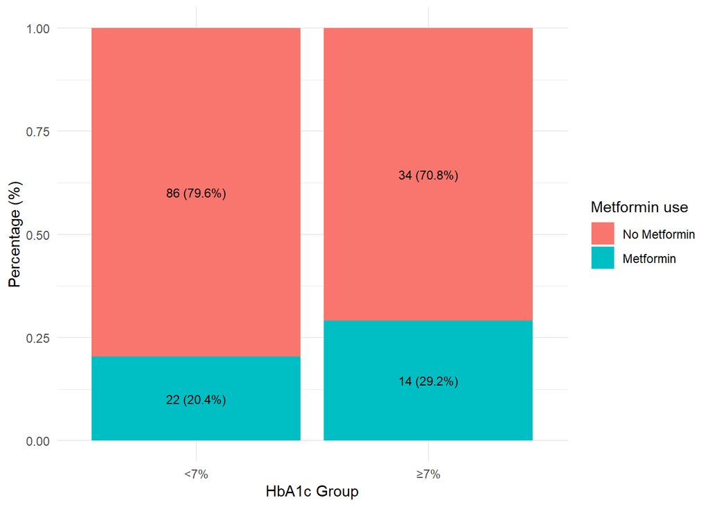

```r
ggplot(overlap_tbl, aes(x = hba1c_group, y = pct, fill = metformin_use)) +
  geom_col() +
  geom_text(aes(label = paste0(n, " (", scales::percent(pct, accuracy = 0.1), ")")),
            position = position_stack(vjust = 0.5), size = 3) +
  labs(x = "HbA1c Group",
       y = "Percentage (%)",
       fill = "Metformin use") +
  theme_minimal()
```

HbA1c <7%：108

Metformin: 22（20.4%）

No Metformin: 86 （79.6%）

HbA1c ≥7%: 48

Metformin: 14（29.2%）

No Metformin: 34（70.8%）

This indicates that both layers simultaneously contain “use/non-use”, with basic overlap, but the number of people using the medication is relatively small. Especially, for ≥7% and Metformin, the number is only n=14. When conducting the interaction test of Metformin × HbA1c, the reliability of the results may be compromised.

```r
# wald
# lrt

cc <- patient_cohort_flagged %>%
  filter(!is.na(hba1c_prior_value)) %>%
  mutate(hba1c_group = ifelse(hba1c_prior_value < 7, "<7%", "≥7%"))

fit0 <- coxph(Surv(os_days, death_event) ~ metformin_use + hba1c_group, data = cc)
fit1 <- coxph(Surv(os_days, death_event) ~ metformin_use*hba1c_group, data = cc)

wald_p <- summary(fit1)$coeff["metformin_use:hba1c_group≥7%", "Pr(>|z|)"]
lrt    <- anova(fit0, fit1, test = "LRT")

wald_p
```

```
## [1] 0.6604856
```

```r
lrt
```

```
## Analysis of Deviance Table
##  Cox model: response is  Surv(os_days, death_event)
##  Model 1: ~ metformin_use + hba1c_group
##  Model 2: ~ metformin_use * hba1c_group
##    loglik  Chisq Df Pr(>|Chi|)
## 1 -156.16
## 2 -156.06 0.2082  1     0.6482
```

```r
# km plot
km_df <- cc %>%
  dplyr::filter(!is.na(hba1c_group),
                !is.na(os_days),
                !is.na(death_event),
                os_days >= 0) %>%
  dplyr::mutate(
    hba1c_group   = factor(hba1c_group, levels = c("<7%", "≥7%")),
    metformin_use = factor(metformin_use, levels = c(0, 1),
                           labels = c("No Metformin", "Metformin"))
  )

n_counts <- table(km_df$hba1c_group)
legend_labs <- paste0(levels(km_df$hba1c_group),
                      " (n=", as.integer(n_counts[levels(km_df$hba1c_group)]), ")")

fit_km <- survfit(Surv(os_days, death_event) ~ hba1c_group, data = km_df)

p_overall <- ggsurvplot(
  fit_km, data = km_df,
  risk.table = TRUE,
  conf.int   = TRUE,
  pval       = TRUE,
  legend.title = "HbA1c prior to pembro",
  legend.labs  = legend_labs,
  xlab = "Days since pembrolizumab initiation",
  ylab = "Overall survival probability",
  break.time.by = 180,
  censor.shape = 124
)
```

```
## Ignoring unknown labels:
## • linetype : "1"
```

```r
fit_km_facet <- survfit(Surv(os_days, death_event) ~ hba1c_group + metformin_use, data = km_df)

p_facet <- ggsurvplot(
  fit_km_facet, data = km_df,
  facet.by    = "metformin_use",
  risk.table  = TRUE,
  conf.int    = FALSE,
  pval        = TRUE,
  legend.title = "HbA1c group",
  legend.labs  = c("<7%", "≥7%"),
  xlab = "Days since pembrolizumab initiation",
  ylab = "Overall survival probability",
  break.time.by = 180,
  censor.shape = 124
)
```

```
## Ignoring unknown labels:
## • fill : "HbA1c group"
## • linetype : "1"
```

```r
p_overall
```

```
## Ignoring unknown labels:
## • linetype : "1"
## Ignoring unknown labels:
## • linetype : "1"
## Ignoring unknown labels:
## • linetype : "1"
## Ignoring unknown labels:
## • colour : "HbA1c prior to pembro"
```

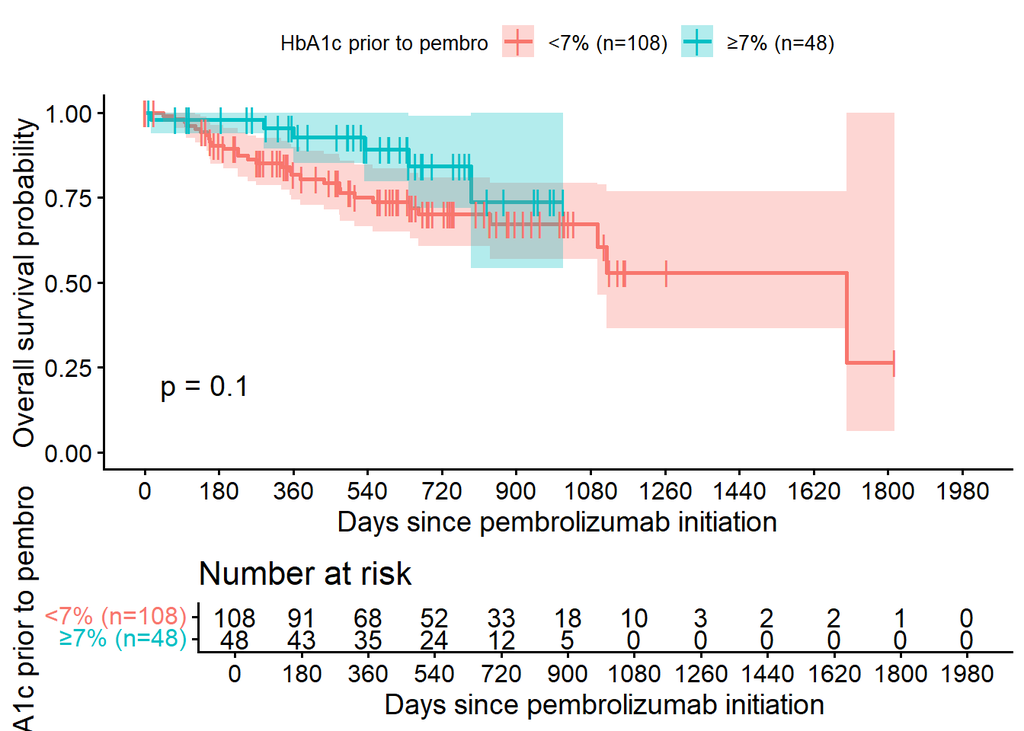

```r
p_facet
```

```
## Ignoring unknown labels:
## • fill : "HbA1c group"
## • linetype : "1"
```

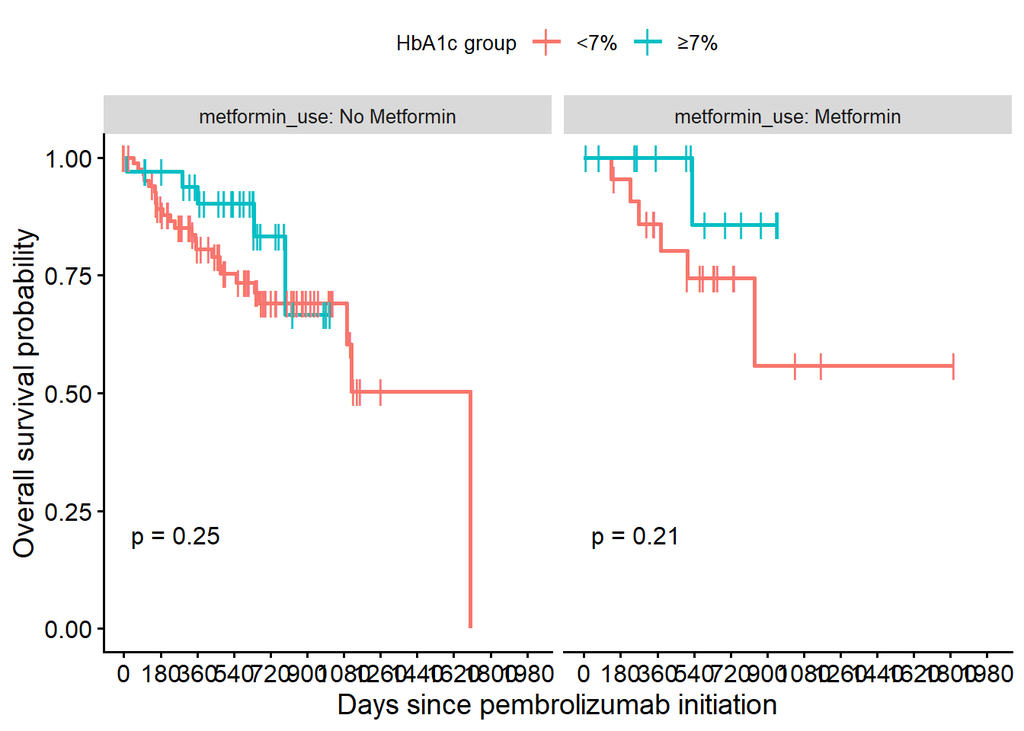

```r
# HR

# helper to get HR, CI, p
lincon_cox <- function(fit, L, label){
  b   <- coef(fit)
  V   <- vcov(fit)
  est <- as.numeric(L %*% b)
  se  <- sqrt(as.numeric(L %*% V %*% t(L)))
  z   <- est / se
  p   <- 2 * pnorm(-abs(z))
  tibble(
    stratum = label,
    logHR   = est,
    HR      = exp(est),
    CI_low  = exp(est - 1.96*se),
    CI_high = exp(est + 1.96*se),
    p_value = p
  )
}

# Find the coefficient names to build the right contrasts
coef_names <- names(coef(fit1))

make_contrast <- function(coef_names, ones) {
  v <- setNames(numeric(length(coef_names)), coef_names)
  v[intersect(names(v), ones)] <- 1
  matrix(v, nrow = 1)
}

L_low  <- make_contrast(coef_names, ones = c("metformin_use"))

L_high <- make_contrast(coef_names, ones = c("metformin_use",
                                             "metformin_use:hba1c_group≥7%"))

lincon_cox <- function(fit, L, label){
  b   <- coef(fit)
  V   <- vcov(fit)
  est <- as.numeric(L %*% b)
  se  <- sqrt(as.numeric(L %*% V %*% t(L)))
  z   <- est / se
  p   <- 2 * pnorm(-abs(z))
  tibble::tibble(
    stratum = label,
    logHR   = est,
    HR      = exp(est),
    CI_low  = exp(est - 1.96*se),
    CI_high = exp(est + 1.96*se),
    p_value = p
  )
}

hr_table_interaction <- dplyr::bind_rows(
  lincon_cox(fit1, L_low,  label = "HbA1c < 7%"),
  lincon_cox(fit1, L_high, label = "HbA1c ≥ 7%")
) %>%
  dplyr::mutate(
    HR_CI = sprintf("%.2f (%.2f–%.2f)", HR, CI_low, CI_high),
    p_fmt = ifelse(p_value < .001, "<0.001", sprintf("%.3f", p_value))
  ) %>%
  dplyr::select(stratum, HR, CI_low, CI_high, HR_CI, p_value, p_fmt)

hr_table_interaction
```

```
## # A tibble: 2 × 7
##   stratum       HR CI_low CI_high HR_CI            p_value p_fmt
##   <chr>      <dbl>  <dbl>   <dbl> <chr>              <dbl> <chr>
## 1 HbA1c < 7% 0.853 0.346     2.10 0.85 (0.35–2.10)   0.730 0.730
## 2 HbA1c ≥ 7% 0.506 0.0591    4.33 0.51 (0.06–4.33)   0.534 0.534
```

Given the limited number of patients in key strata and the lack of statistical support for formal interaction analyses, additional stratified Kaplan–Meier analyses are underpowered and unlikely to yield reliable conclusions.

# Subgroup analysis - Metastatic

```r
filtered_secondary <- standardized_terminology[grepl("secondary malignant|Secondary and unspecified malignant", standardized_terminology$code_description, ignore.case = TRUE), ] %>%
  filter(!code %in% c("198.2","C79.2","C79.81","198.81")) #remove codes for skin neoplasm and secondary breast, as they are not signs for metastasized breast cancer

diagnosis_secondary <- diagnosis_cohort %>%
  filter(code %in% filtered_secondary$code) %>%
  select(patient_id, code_system, date, code) %>%
  left_join(filtered_secondary %>% select(code, code_description), by = "code") %>%
  left_join(patient_cohort_flagged %>% select(patient_id, BC_diagnosis_date, pembro_initiation), by = "patient_id") %>%
  filter(date >= BC_diagnosis_date & date <= pembro_initiation) %>%
  distinct(patient_id, code, .keep_all = TRUE)
patient_cohort_flagged <- patient_cohort_flagged |>
  mutate(metastatic = ifelse(patient_id %in% diagnosis_secondary$patient_id,1,0))
```

# Table 1

```r
# Clean and label dataset
tab1 <- patient_cohort_flagged |>
  mutate(
    metformin = factor(metformin, labels = c("No", "Yes")),
    death_event = factor(death_event, levels= c(0,1), labels = c("No", "Yes")),
    insulin_at_pembro = factor(insulin_at_pembro, levels= c(0,1), labels = c("No", "Yes"))
  ) |>
  select(
    metformin,
    age_at_pembro_initiation,
    age_at_diagnosis,
    age_at_met_initiation,
    year_of_pembro_initiation,
    years_between_met_and_pembro,
    days_on_pembro,
    surgery,
    chemo,
    hba1c_prior_value,
    radiation,
    bmi_value,
    tamoxifen_ai_status,
    insulin_at_pembro,
    num_other_med_classes,
    num_other_meds,
    obesity,
    hypertension,
    hyperlipidemia,
    liver_disease,
    kidney_disease,
    num_comorbidities,
    metastatic,
    death_event
  )

# Create labeled Table One
tab1 %>%
  tbl_summary(
    by = metformin,
    label = list(
      age_at_pembro_initiation ~ "Age at Pembrolizumab Initiation",
      age_at_diagnosis ~ "Age at Diagnosis",
      age_at_met_initiation ~ "Age at Metformin Initiation",
      year_of_pembro_initiation ~ "Year of Pembrolizumab Initiation",
      years_between_met_and_pembro ~ "Duration of metformin use before pembro (Years)",
      days_on_pembro ~ "Time on Pembrolizumab (Days)",
      surgery ~ "Surgery",
      chemo ~ "Chemotherapy",
      hba1c_prior_value ~ "HbA1c Prior to Pembro Initiation (%)",
      radiation ~ "Radiation Therapy",
      bmi_value ~ "Latest BMI",
      tamoxifen_ai_status ~ "Tamoxifen/AI Status",
      insulin_at_pembro ~ "Insulin Use",
      num_other_med_classes ~ "Other Diabetes Medication Classes",
      num_other_meds ~ "Other Diabetes Medications",
      obesity ~ "Obesity",
      hypertension ~ "Hypertension",
      hyperlipidemia ~ "Hyperlipidemia",
      liver_disease ~ "Liver Disease",
      kidney_disease ~ "Kidney Disease",
      num_comorbidities ~ "Comorbidities Total",
      metastatic ~ "Metastatic",
      death_event ~ "Death Event"
    ),
    missing = "ifany"
  ) %>%
  add_p() %>%
  add_overall() %>%
  modify_caption("**Table 1. Patient Characteristics by Metformin Use**") %>%
  bold_labels()
```

[output not shown]

**Table 1. Patient Characteristics by Metformin Use**

| **Characteristic** | **Overall** N = 483<sup>1</sup> | **No** N = 355<sup>1</sup> | **Yes** N = 128<sup>1</sup> | **p-value**<sup>2</sup> |
| --- | --- | --- | --- | --- |
| Age at Pembrolizumab Initiation | 60 (53, 66) | 60 (52, 67) | 60 (53, 64) | 0.4 |
| Age at Diagnosis | 59 (52, 66) | 60 (51, 66) | 59 (53, 64) | 0.4 |
| Age at Metformin Initiation | 54 (48, 60) | NA (NA, NA) | 54 (48, 60) |  |
| Unknown | 355 | 355 | 0 |  |
| Year of Pembrolizumab Initiation |  |  |  | 0.12 |
| 2019 | 9 (1.9%) | 7 (2.0%) | 2 (1.6%) |  |
| 2020 | 17 (3.5%) | 10 (2.8%) | 7 (5.5%) |  |
| 2021 | 57 (12%) | 46 (13%) | 11 (8.6%) |  |
| 2022 | 158 (33%) | 106 (30%) | 52 (41%) |  |
| 2023 | 156 (32%) | 116 (33%) | 40 (31%) |  |
| 2024 | 85 (18%) | 69 (19%) | 16 (13%) |  |
| 2025 | 1 (0.2%) | 1 (0.3%) | 0 (0%) |  |
| Duration of metformin use before pembro (Years) | 0.00 (0.00, 0.47) | 0.00 (0.00, 0.00) | 4.77 (2.10, 7.33) | <0.001 |
| Time on Pembrolizumab (Days) | 175 (51, 343) | 154 (49, 336) | 268 (84, 364) | 0.009 |
| Surgery | 313 (65%) | 230 (65%) | 83 (65%) | >0.9 |
| Chemotherapy |  |  |  |  |
| yes | 483 (100%) | 355 (100%) | 128 (100%) |  |
| HbA1c Prior to Pembro Initiation (%) | 6.30 (5.70, 7.30) | 6.15 (5.70, 7.10) | 6.65 (6.10, 7.80) | 0.018 |
| Unknown | 327 | 235 | 92 |  |
| Radiation Therapy | 83 (17%) | 63 (18%) | 20 (16%) | 0.6 |
| Latest BMI | 30 (26, 36) | 30 (25, 36) | 31 (27, 37) | 0.4 |
| Unknown | 214 | 153 | 61 |  |
| Tamoxifen/AI Status |  |  |  | 0.4 |
| ai_only | 18 (3.7%) | 12 (3.4%) | 6 (4.7%) |  |
| both | 3 (0.6%) | 2 (0.6%) | 1 (0.8%) |  |
| no | 456 (94%) | 338 (95%) | 118 (92%) |  |
| tamoxifen_only | 6 (1.2%) | 3 (0.8%) | 3 (2.3%) |  |
| Insulin Use | 62 (13%) | 41 (12%) | 21 (16%) | 0.2 |
| Other Diabetes Medication Classes |  |  |  | <0.001 |
| 0 | 345 (71%) | 284 (80%) | 61 (48%) |  |
| 1 | 83 (17%) | 50 (14%) | 33 (26%) |  |
| 2+ | 55 (11%) | 21 (5.9%) | 34 (27%) |  |
| Other Diabetes Medications |  |  |  | <0.001 |
| 0 | 374 (77%) | 310 (87%) | 64 (50%) |  |
| 1 | 78 (16%) | 36 (10%) | 42 (33%) |  |
| 2 | 21 (4.3%) | 5 (1.4%) | 16 (13%) |  |
| 3+ | 10 (2.1%) | 4 (1.1%) | 6 (4.7%) |  |
| Obesity | 203 (42%) | 149 (42%) | 54 (42%) | >0.9 |
| Hypertension | 347 (72%) | 239 (67%) | 108 (84%) | <0.001 |
| Hyperlipidemia | 278 (58%) | 189 (53%) | 89 (70%) | 0.001 |
| Liver Disease | 27 (5.6%) | 26 (7.3%) | 1 (0.8%) | 0.006 |
| Kidney Disease | 73 (15%) | 58 (16%) | 15 (12%) | 0.2 |
| Comorbidities Total |  |  |  |  |
| 0 | 71 (15%) | 61 (17%) | 10 (7.8%) |  |
| 1 | 102 (21%) | 78 (22%) | 24 (19%) |  |
| 2 | 152 (31%) | 106 (30%) | 46 (36%) |  |
| 3 | 114 (24%) | 73 (21%) | 41 (32%) |  |
| 4 | 40 (8.3%) | 33 (9.3%) | 7 (5.5%) |  |
| 5 | 4 (0.8%) | 4 (1.1%) | 0 (0%) |  |
| Metastatic | 253 (52%) | 188 (53%) | 65 (51%) | 0.7 |
| Death Event | 101 (21%) | 81 (23%) | 20 (16%) | 0.086 |

<sup>1</sup> Median (Q1, Q3); n (%)  
<sup>2</sup> Wilcoxon rank sum test; Fisher’s exact test; Pearson’s Chi-squared test

# Kaplan Meier Curves

## Comparing Metformin Use Overall to None

```
## Ignoring unknown labels:
## • linetype : "1"
```

```
## Ignoring unknown labels:
## • linetype : "1"
```

```
## Ignoring unknown labels:
## • linetype : "1"
## Ignoring unknown labels:
## • linetype : "1"
```

```
## Ignoring unknown labels:
## • colour : "Metformin Use"
```

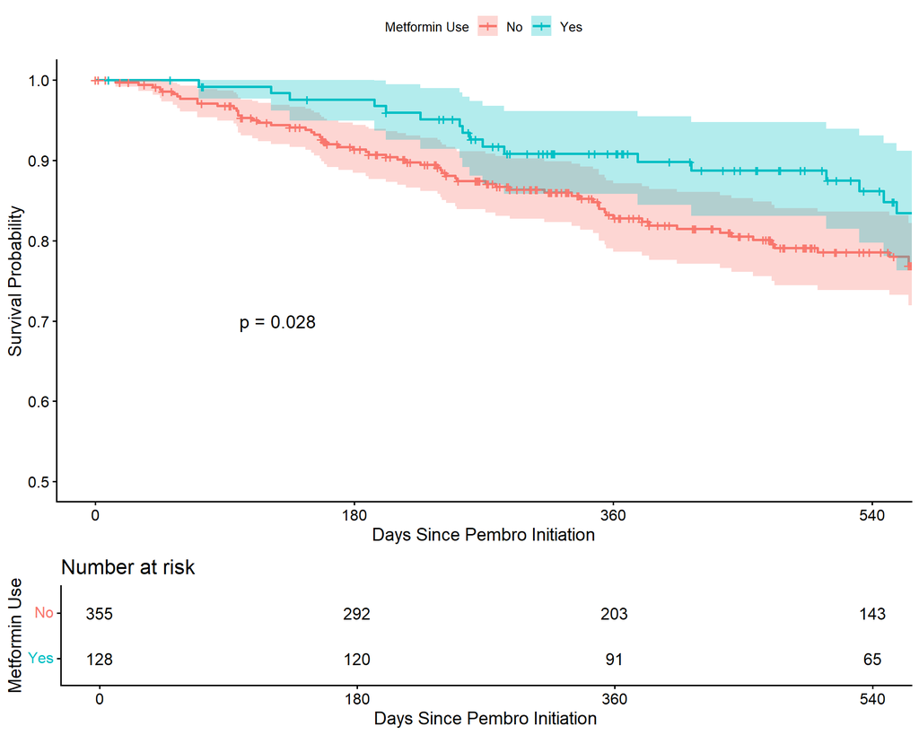

```r
surv_object <- Surv(time = patient_cohort_flagged$os_days, event = patient_cohort_flagged$death_event)

fit_km2 <- survfit(surv_object ~ metformin, data = patient_cohort_flagged)

ggsurvplot(
  fit_km2,
  data = patient_cohort_flagged,
  pval = TRUE,
  pval.coord = c(100, 0.7),
  conf.int = TRUE,
  risk.table = TRUE,
  legend.title = "Metformin Use",
  legend.labs = c("No", "Yes"),
  xlab = "Days Since Pembro Initiation",
  ylab = "Survival Probability",
  ylim = c(0.5,1),
  xlim = c(0, 540),
  break.time.by = 180  # 0, 180, 360 automatically
)
```

## Comparing 4 Categories of Metformin Use

### metformin_years_at_pembro_tertile

```r
# Step 1: Get tertile cutoffs (including max)
met_users <- patient_cohort_flagged %>% filter(metformin == 1)
tertile_cutoffs2 <- quantile(met_users$years_between_met_and_pembro, probs = seq(0, 1, 1/3), na.rm = TRUE)

# Step 2: Round cutoffs for readable labels
t1 <- round(tertile_cutoffs2[1], 1)
t2 <- round(tertile_cutoffs2[2], 1)
t3 <- round(tertile_cutoffs2[3], 1)
t4 <- ceiling(tertile_cutoffs2[4])  # This is the max

# Step 3: Create labeled and factored tertile variable
patient_cohort_flagged <- patient_cohort_flagged %>%
  mutate(
    metformin_years_at_pembro_tertile = case_when(
      metformin == 0 ~ "0",
      metformin == 1 & years_between_met_and_pembro <= t2 ~ paste0(t1, "–", t2, " yrs"),
      metformin == 1 & years_between_met_and_pembro <= t3 ~ paste0(t2 + 0.01, "–", t3, " yrs"),
      metformin == 1 & years_between_met_and_pembro <= t4 ~ paste0(t3 + 0.01, "–", t4, " yrs"),
      TRUE ~ NA_character_
    ),
    metformin_years_at_pembro_tertile = factor(
      metformin_years_at_pembro_tertile,
      levels = c(
        "0",
        paste0(t1, "–", t2, " yrs"),
        paste0(t2 + 0.01, "–", t3, " yrs"),
        paste0(t3 + 0.01, "–", t4, " yrs")
      )
    )
  )
```

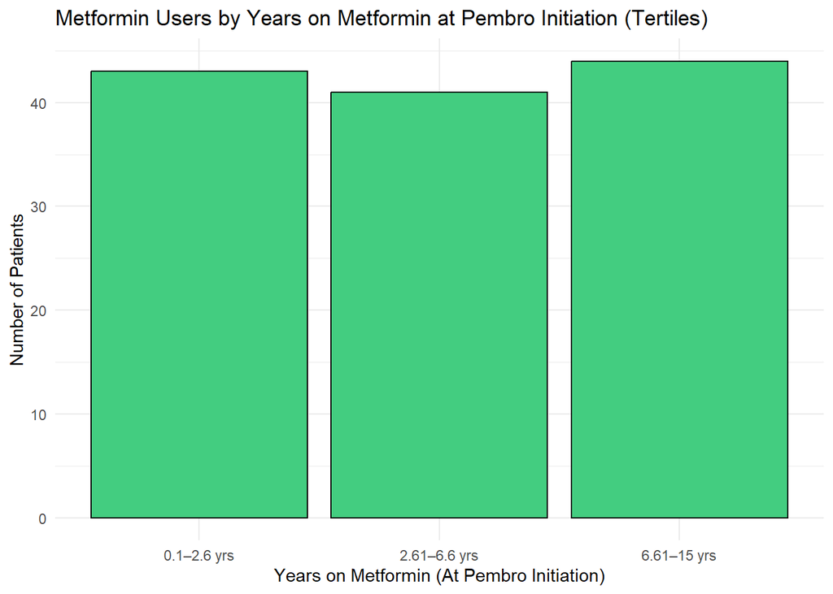

```r
ggplot(
  data = patient_cohort_flagged %>% filter(metformin == 1),
  aes(x = metformin_years_at_pembro_tertile)
) +
  geom_bar(fill = "seagreen3", color = "black") +
  labs(
    title = "Metformin Users by Years on Metformin at Pembro Initiation (Tertiles)",
    x = "Years on Metformin (At Pembro Initiation)",
    y = "Number of Patients"
  ) +
  theme_minimal()
```

```
## Ignoring unknown labels:
## • linetype : "1"
```

```
## Ignoring unknown labels:
## • linetype : "1"
```

```
## Ignoring unknown labels:
## • linetype : "1"
## Ignoring unknown labels:
## • linetype : "1"
```

```
## Ignoring unknown labels:
## • colour : "Metformin Use at Pembro Initiation (Years)"
```

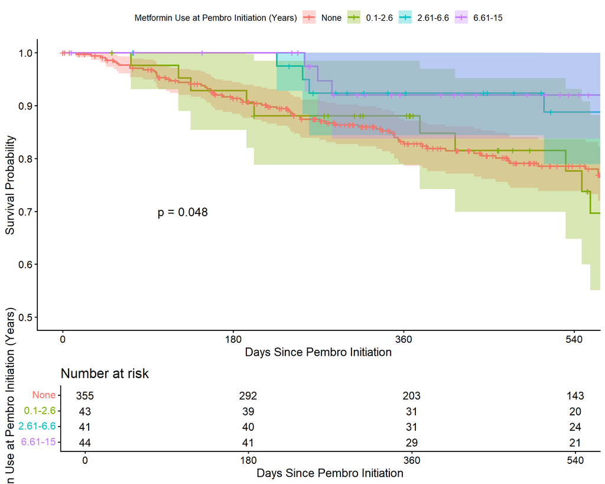

```r
surv_object <- Surv(time = patient_cohort_flagged$os_days, event = patient_cohort_flagged$death_event)

fit_km <- survfit(surv_object ~ metformin_years_at_pembro_tertile, data = patient_cohort_flagged)

# Plot with survival estimates at 6 months and 1 year
ggsurvplot(
  fit_km,
  data = patient_cohort_flagged,
  pval = TRUE,
  pval.coord = c(100, 0.7),
  conf.int = TRUE,
  risk.table = TRUE,
  legend.title = "Metformin Use at Pembro Initiation (Years)",
  legend.labs = c("None", "0.1-2.6", "2.61-6.6", "6.61-15"),
  xlab = "Days Since Pembro Initiation",
  ylab = "Survival Probability",
  ylim = c(0.5, 1),
  xlim = c(0, 540),
  break.time.by = 180  # 0, 180, 360 automatically
)
```

## By Metastatic Status

```
## Ignoring unknown labels:
## • linetype : "1"
```

```
## Ignoring unknown labels:
## • linetype : "1"
```

```
## Ignoring unknown labels:
## • linetype : "1"
## Ignoring unknown labels:
## • linetype : "1"
```

```
## Ignoring unknown labels:
## • colour : "Metformin Use"
```

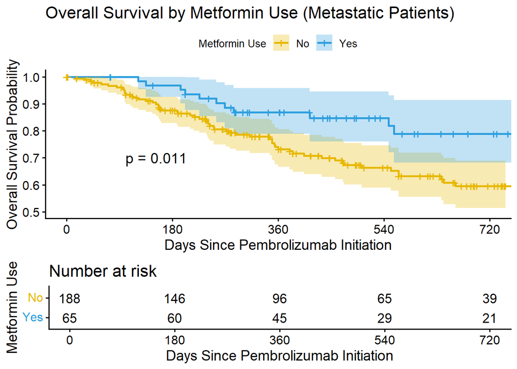

```r
# Stratified Cox models by metastatic status
# Metastatic Patients (metastatic = 1)
fit_meta_yes <- survfit(Surv(os_days, death_event) ~ metformin,
                        data = patient_cohort_flagged %>% filter(metastatic == 1))

ggsurvplot(
  fit_meta_yes,
  data = patient_cohort_flagged %>% filter(metastatic == 1),
  pval = TRUE,
  pval.coord = c(100, 0.7),
  risk.table = TRUE,
  conf.int = TRUE,
  xlab = "Days Since Pembrolizumab Initiation",
  ylab = "Overall Survival Probability",
  title = "Overall Survival by Metformin Use (Metastatic Patients)",
  legend.title = "Metformin Use",
  legend.labs = c("No", "Yes"),
  palette = c("#E7B800", "#2E9FDF"),
  ylim = c(0.5,1),
  xlim = c(0, 720),
  break.time.by = 180,  # 0, 180, 360 automatically
  risk.table.height = 0.3
)
```

```
## Ignoring unknown labels:
## • linetype : "1"
```

```
## Ignoring unknown labels:
## • linetype : "1"
```

```
## Ignoring unknown labels:
## • linetype : "1"
## Ignoring unknown labels:
## • linetype : "1"
```

```
## Ignoring unknown labels:
## • colour : "Metformin Use"
```

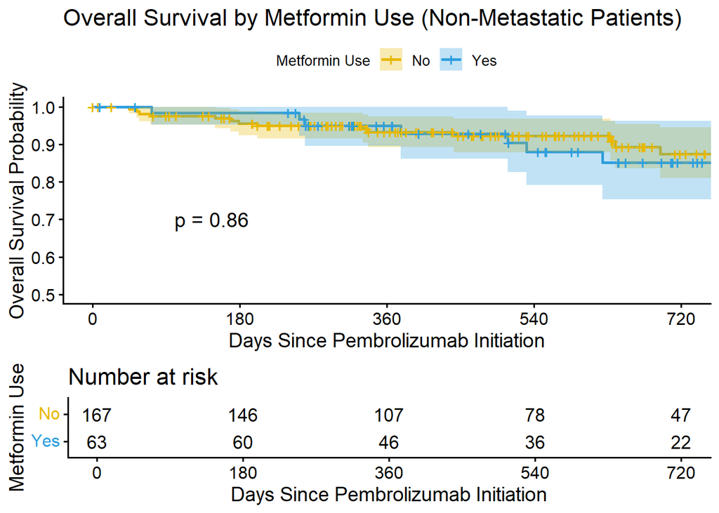

```r
# Non-Metastatic Patients (metastatic = 0)
fit_meta_no <- survfit(Surv(os_days, death_event) ~ metformin,
                       data = patient_cohort_flagged %>% filter(metastatic == 0))

ggsurvplot(
  fit_meta_no,
  data = patient_cohort_flagged %>% filter(metastatic == 0),
  pval = TRUE,
  pval.coord = c(100, 0.7),
  risk.table = TRUE,
  conf.int = TRUE,
  xlab = "Days Since Pembrolizumab Initiation",
  ylab = "Overall Survival Probability",
  title = "Overall Survival by Metformin Use (Non-Metastatic Patients)",
  legend.title = "Metformin Use",
  legend.labs = c("No", "Yes"),
  palette = c("#E7B800", "#2E9FDF"),
  ylim = c(0.5,1),
  xlim = c(0, 720),
  break.time.by = 180,  # 0, 180, 360 automatically
  risk.table.height = 0.3
)
```

# Cox Proportional Hazards Models

## Choosing a model

```r
# Fit Cox proportional hazards model - with metformin (yes/no) and duration
cox_model_test_og <- coxph(Surv(os_days, death_event) ~ metformin + years_between_met_and_pembro + age_at_pembro_initiation + year_of_pembro_initiation + surgery + radiation + insulin_at_pembro + num_comorbidities + num_other_med_classes, data = patient_cohort_flagged)

# Summarize the model
summary(cox_model_test_og)
```

```
## Call:
## coxph(formula = Surv(os_days, death_event) ~ metformin + years_between_met_and_pembro +
##     age_at_pembro_initiation + year_of_pembro_initiation + surgery +
##     radiation + insulin_at_pembro + num_comorbidities + num_other_med_classes,
##     data = patient_cohort_flagged)
##
##   n= 483, number of events= 101
##
##                                  coef exp(coef) se(coef)      z Pr(>|z|)
## metformin                     0.19066   1.21004  0.40699  0.468 0.639461
## years_between_met_and_pembro -0.12119   0.88587  0.07671 -1.580 0.114136
## age_at_pembro_initiation      0.01676   1.01690  0.01048  1.599 0.109768
## year_of_pembro_initiation    -0.05296   0.94842  0.09599 -0.552 0.581173
## surgeryyes                   -0.60056   0.54851  0.20783 -2.890 0.003857 **
## radiationyes                  0.78817   2.19937  0.22900  3.442 0.000578 ***
## insulin_at_pembro1            0.71122   2.03648  0.41022  1.734 0.082964 .
## num_comorbidities             0.10650   1.11237  0.08768  1.215 0.224515
## num_other_med_classes1       -0.06615   0.93599  0.34489 -0.192 0.847907
## num_other_med_classes2+      -1.47523   0.22873  0.54382 -2.713 0.006673 **
## ---
## Signif. codes:  0 '***' 0.001 '**' 0.01 '*' 0.05 '.' 0.1 ' ' 1
##
##                              exp(coef) exp(-coef) lower .95 upper .95
## metformin                       1.2100     0.8264   0.54496    2.6868
## years_between_met_and_pembro    0.8859     1.1288   0.76221    1.0296
## age_at_pembro_initiation        1.0169     0.9834   0.99623    1.0380
## year_of_pembro_initiation       0.9484     1.0544   0.78576    1.1448
## surgeryyes                      0.5485     1.8231   0.36498    0.8243
## radiationyes                    2.1994     0.4547   1.40402    3.4453
## insulin_at_pembro1              2.0365     0.4910   0.91137    4.5505
## num_comorbidities               1.1124     0.8990   0.93674    1.3209
## num_other_med_classes1          0.9360     1.0684   0.47610    1.8401
## num_other_med_classes2+         0.2287     4.3721   0.07878    0.6641
##
## Concordance= 0.7  (se = 0.027 )
## Likelihood ratio test= 49.66  on 10 df,   p=3e-07
## Wald test            = 48.03  on 10 df,   p=6e-07
## Score (logrank) test = 50.24  on 10 df,   p=2e-07
```

```r
# Fit Cox proportional hazards model - with just metformin duration
cox_model_test_metformin_duration <- coxph(Surv(os_days, death_event) ~ years_between_met_and_pembro + age_at_pembro_initiation + year_of_pembro_initiation + surgery + radiation + insulin_at_pembro + num_comorbidities + num_other_med_classes, data = patient_cohort_flagged)

# Summarize the model
summary(cox_model_test_metformin_duration)
```

```
## Call:
## coxph(formula = Surv(os_days, death_event) ~ years_between_met_and_pembro +
##     age_at_pembro_initiation + year_of_pembro_initiation + surgery +
##     radiation + insulin_at_pembro + num_comorbidities + num_other_med_classes,
##     data = patient_cohort_flagged)
##
##   n= 483, number of events= 101
##
##                                  coef exp(coef) se(coef)      z Pr(>|z|)
## years_between_met_and_pembro -0.09422   0.91008  0.04851 -1.942 0.052104 .
## age_at_pembro_initiation      0.01623   1.01636  0.01041  1.560 0.118824
## year_of_pembro_initiation    -0.05511   0.94638  0.09595 -0.574 0.565728
## surgeryyes                   -0.60182   0.54781  0.20772 -2.897 0.003764 **
## radiationyes                  0.78407   2.19037  0.22918  3.421 0.000623 ***
## insulin_at_pembro1            0.67554   1.96508  0.40305  1.676 0.093724 .
## num_comorbidities             0.10942   1.11563  0.08733  1.253 0.210195
## num_other_med_classes1       -0.05113   0.95015  0.34348 -0.149 0.881657
## num_other_med_classes2+      -1.45143   0.23423  0.54257 -2.675 0.007470 **
## ---
## Signif. codes:  0 '***' 0.001 '**' 0.01 '*' 0.05 '.' 0.1 ' ' 1
##
##                              exp(coef) exp(-coef) lower .95 upper .95
## years_between_met_and_pembro    0.9101     1.0988   0.82754    1.0009
## age_at_pembro_initiation        1.0164     0.9839   0.99584    1.0373
## year_of_pembro_initiation       0.9464     1.0567   0.78414    1.1422
## surgeryyes                      0.5478     1.8254   0.36461    0.8231
## radiationyes                    2.1904     0.4565   1.39778    3.4324
## insulin_at_pembro1              1.9651     0.5089   0.89188    4.3297
## num_comorbidities               1.1156     0.8964   0.94013    1.3239
## num_other_med_classes1          0.9502     1.0525   0.48464    1.8628
## num_other_med_classes2+         0.2342     4.2692   0.08088    0.6784
##
## Concordance= 0.701  (se = 0.027 )
## Likelihood ratio test= 49.45  on 9 df,   p=1e-07
## Wald test            = 47.93  on 9 df,   p=3e-07
## Score (logrank) test = 50.21  on 9 df,   p=1e-07
```

```r
# Fit Cox proportional hazards model - with just metformin (yes/no)
cox_model_test_metformin_binary <- coxph(Surv(os_days, death_event) ~ metformin + age_at_pembro_initiation + year_of_pembro_initiation + surgery + radiation + insulin_at_pembro + num_comorbidities + num_other_med_classes, data = patient_cohort_flagged)

# Summarize the model
summary(cox_model_test_metformin_binary)
```

```
## Call:
## coxph(formula = Surv(os_days, death_event) ~ metformin + age_at_pembro_initiation +
##     year_of_pembro_initiation + surgery + radiation + insulin_at_pembro +
##     num_comorbidities + num_other_med_classes, data = patient_cohort_flagged)
##
##   n= 483, number of events= 101
##
##                               coef exp(coef) se(coef)      z Pr(>|z|)
## metformin                 -0.36871   0.69163  0.26297 -1.402  0.16088
## age_at_pembro_initiation   0.01597   1.01610  0.01047  1.526  0.12703
## year_of_pembro_initiation -0.06041   0.94138  0.09586 -0.630  0.52860
## surgeryyes                -0.59624   0.55088  0.20758 -2.872  0.00407 **
## radiationyes               0.75253   2.12235  0.22907  3.285  0.00102 **
## insulin_at_pembro1         0.67772   1.96938  0.41025  1.652  0.09854 .
## num_comorbidities          0.11270   1.11929  0.08717  1.293  0.19605
## num_other_med_classes1    -0.09876   0.90596  0.34545 -0.286  0.77497
## num_other_med_classes2+   -1.49653   0.22390  0.54685 -2.737  0.00621 **
## ---
## Signif. codes:  0 '***' 0.001 '**' 0.01 '*' 0.05 '.' 0.1 ' ' 1
##
##                           exp(coef) exp(-coef) lower .95 upper .95
## metformin                    0.6916     1.4459   0.41308    1.1580
## age_at_pembro_initiation     1.0161     0.9842   0.99547    1.0372
## year_of_pembro_initiation    0.9414     1.0623   0.78013    1.1360
## surgeryyes                   0.5509     1.8153   0.36674    0.8275
## radiationyes                 2.1224     0.4712   1.35466    3.3251
## insulin_at_pembro1           1.9694     0.5078   0.88130    4.4008
## num_comorbidities            1.1193     0.8934   0.94351    1.3278
## num_other_med_classes1       0.9060     1.1038   0.46033    1.7830
## num_other_med_classes2+      0.2239     4.4662   0.07666    0.6540
##
## Concordance= 0.695  (se = 0.027 )
## Likelihood ratio test= 46.9  on 9 df,   p=4e-07
## Wald test            = 46.31  on 9 df,   p=5e-07
## Score (logrank) test = 48.64  on 9 df,   p=2e-07
```

```r
# Assess whether each model improves on the original
anova(cox_model_test_metformin_binary, cox_model_test_og, test="LRT")
```

```
## Analysis of Deviance Table
##  Cox model: response is  Surv(os_days, death_event)
##  Model 1: ~ metformin + age_at_pembro_initiation + year_of_pembro_initiation + surgery + radiation + insulin_at_pembro + num_comorbidities + num_other_med_classes
##  Model 2: ~ metformin + years_between_met_and_pembro + age_at_pembro_initiation + year_of_pembro_initiation + surgery + radiation + insulin_at_pembro + num_comorbidities + num_other_med_classes
##    loglik  Chisq Df Pr(>|Chi|)
## 1 -535.49
## 2 -534.12 2.7579  1    0.09678 .
## ---
## Signif. codes:  0 '***' 0.001 '**' 0.01 '*' 0.05 '.' 0.1 ' ' 1
```

```r
anova(cox_model_test_metformin_duration, cox_model_test_og, test="LRT")
```

```
## Analysis of Deviance Table
##  Cox model: response is  Surv(os_days, death_event)
##  Model 1: ~ years_between_met_and_pembro + age_at_pembro_initiation + year_of_pembro_initiation + surgery + radiation + insulin_at_pembro + num_comorbidities + num_other_med_classes
##  Model 2: ~ metformin + years_between_met_and_pembro + age_at_pembro_initiation + year_of_pembro_initiation + surgery + radiation + insulin_at_pembro + num_comorbidities + num_other_med_classes
##    loglik  Chisq Df Pr(>|Chi|)
## 1 -534.22
## 2 -534.12 0.2139  1     0.6437
```

```r
# Compare the AIC of the three models, to find model with lowest AIC
AIC(cox_model_test_metformin_duration, cox_model_test_metformin_binary, cox_model_test_og)
```

```
##                                   df      AIC
## cox_model_test_metformin_duration  9 1086.445
## cox_model_test_metformin_binary    9 1088.989
## cox_model_test_og                 10 1088.231
```

## Assumption test for cox-model

```r
library(survival)

zph_og <- cox.zph(cox_model_test_og, transform = "km")
print(zph_og)
```

```
##                                chisq df     p
## metformin                     0.0125  1 0.911
## years_between_met_and_pembro  0.0242  1 0.876
## age_at_pembro_initiation      0.4805  1 0.488
## year_of_pembro_initiation     0.9103  1 0.340
## surgery                       1.3402  1 0.247
## radiation                     0.1721  1 0.678
## insulin_at_pembro             0.0332  1 0.855
## num_comorbidities             3.7500  1 0.053
## num_other_med_classes         5.0024  2 0.082
## GLOBAL                       16.1195 10 0.096
```

```r
zph_metformin_binary <- cox.zph(cox_model_test_metformin_binary, transform = "km")
print(zph_metformin_binary)
```

```
##                              chisq df     p
## metformin                 1.18e-05  1 0.997
## age_at_pembro_initiation  4.87e-01  1 0.485
## year_of_pembro_initiation 1.09e+00  1 0.296
## surgery                   1.38e+00  1 0.240
## radiation                 5.10e-02  1 0.821
## insulin_at_pembro         7.62e-02  1 0.782
## num_comorbidities         3.68e+00  1 0.055
## num_other_med_classes     5.43e+00  2 0.066
## GLOBAL                    1.59e+01  9 0.069
```

```r
zph_metformin_duration <- cox.zph(cox_model_test_metformin_duration, transform = "km")
print(zph_metformin_duration)
```

```
##                                chisq df     p
## years_between_met_and_pembro  0.0285  1 0.866
## age_at_pembro_initiation      0.4791  1 0.489
## year_of_pembro_initiation     0.9516  1 0.329
## surgery                       1.3388  1 0.247
## radiation                     0.1431  1 0.705
## insulin_at_pembro             0.0286  1 0.866
## num_comorbidities             3.7013  1 0.054
## num_other_med_classes         4.9795  2 0.083
## GLOBAL                       15.8904  9 0.069
```

## Stratified Cox models by metastatic status

```r
# years_between_met_and_pembro
cox_model_test_metformin_binary <- coxph(Surv(os_days, death_event) ~ years_between_met_and_pembro* metastatic + age_at_pembro_initiation + year_of_pembro_initiation + surgery + radiation + insulin_at_pembro + num_comorbidities + num_other_med_classes, data = patient_cohort_flagged)

# Summarize the model
summary(cox_model_test_metformin_binary)
```

```
## Call:
## coxph(formula = Surv(os_days, death_event) ~ years_between_met_and_pembro *
##     metastatic + age_at_pembro_initiation + year_of_pembro_initiation +
##     surgery + radiation + insulin_at_pembro + num_comorbidities +
##     num_other_med_classes, data = patient_cohort_flagged)
##
##   n= 483, number of events= 101
##
##                                               coef  exp(coef)   se(coef)      z
## years_between_met_and_pembro            -0.0179548  0.9822054  0.0803011 -0.224
## metastatic                               1.2090168  3.3501893  0.2617289  4.619
## age_at_pembro_initiation                 0.0149697  1.0150823  0.0104597  1.431
## year_of_pembro_initiation                0.0005623  1.0005624  0.0943598  0.006
## surgeryyes                              -0.7269404  0.4833857  0.2119411 -3.430
## radiationyes                             0.5377880  1.7122152  0.2320518  2.318
## insulin_at_pembro1                       0.5297637  1.6985309  0.4061617  1.304
## num_comorbidities                        0.0511963  1.0525295  0.0909927  0.563
## num_other_med_classes1                   0.0646751  1.0668123  0.3485534  0.186
## num_other_med_classes2+                 -1.3733081  0.2532677  0.5433248 -2.528
## years_between_met_and_pembro:metastatic -0.1125349  0.8935662  0.0988479 -1.138
##                                         Pr(>|z|)
## years_between_met_and_pembro            0.823074
## metastatic                              3.85e-06 ***
## age_at_pembro_initiation                0.152378
## year_of_pembro_initiation               0.995246
## surgeryyes                              0.000604 ***
## radiationyes                            0.020475 *
## insulin_at_pembro1                      0.192125
## num_comorbidities                       0.573679
## num_other_med_classes1                  0.852795
## num_other_med_classes2+                 0.011484 *
## years_between_met_and_pembro:metastatic 0.254926
## ---
## Signif. codes:  0 '***' 0.001 '**' 0.01 '*' 0.05 '.' 0.1 ' ' 1
##
##                                         exp(coef) exp(-coef) lower .95
## years_between_met_and_pembro               0.9822     1.0181   0.83917
## metastatic                                 3.3502     0.2985   2.00579
## age_at_pembro_initiation                   1.0151     0.9851   0.99448
## year_of_pembro_initiation                  1.0006     0.9994   0.83162
```

[output cut: 9 more lines]

```
## metastatic                                 5.5957
## age_at_pembro_initiation                   1.0361
## year_of_pembro_initiation                  1.2038
## surgeryyes                                 0.7323
## radiationyes                               2.6982
## insulin_at_pembro1                         3.7653
## num_comorbidities                          1.2580
## num_other_med_classes1                     2.1124
## num_other_med_classes2+                    0.7346
## years_between_met_and_pembro:metastatic    1.0846
##
## Concordance= 0.732  (se = 0.026 )
## Likelihood ratio test= 74.22  on 11 df,   p=2e-11
## Wald test            = 70.12  on 11 df,   p=1e-10
## Score (logrank) test = 76.95  on 11 df,   p=6e-12
```

In this Cox proportional hazards model, the interaction between metformin duration and metastatic status was not statistically significant (HR = 0.89, p = 0.25), indicating that the survival effect of metformin duration did not differ meaningfully between metastatic and non-metastatic patients. Metastatic disease was strongly associated with higher mortality (HR = 3.35, p < 0.001), while surgery was significantly protective (HR = 0.48, p < 0.001). Radiation therapy (HR = 1.71, p = 0.02) and use of two or more other antidiabetic drug classes (HR = 0.25, p = 0.01) were also independent predictors of survival. Overall, these results suggest that metformin duration alone does not significantly influence survival, but clinical and treatment factors such as metastasis, surgery, and concurrent medications remain key determinants of patient outcomes.

```r
# metformin
cox_model_test_metformin_duration <- coxph(Surv(os_days, death_event) ~ metformin* metastatic + age_at_pembro_initiation + year_of_pembro_initiation + surgery + radiation + insulin_at_pembro + num_comorbidities + num_other_med_classes, data = patient_cohort_flagged)

# Summarize the model
summary(cox_model_test_metformin_duration)
```

```
## Call:
## coxph(formula = Surv(os_days, death_event) ~ metformin * metastatic +
##     age_at_pembro_initiation + year_of_pembro_initiation + surgery +
##     radiation + insulin_at_pembro + num_comorbidities + num_other_med_classes,
##     data = patient_cohort_flagged)
##
##   n= 483, number of events= 101
##
##                                coef exp(coef)  se(coef)      z Pr(>|z|)
## metformin                  0.345957  1.413342  0.443298  0.780 0.435146
## metastatic                 1.348052  3.849918  0.284128  4.745 2.09e-06 ***
## age_at_pembro_initiation   0.015125  1.015240  0.010484  1.443 0.149109
## year_of_pembro_initiation -0.001298  0.998703  0.094593 -0.014 0.989049
## surgeryyes                -0.724172  0.484726  0.212307 -3.411 0.000647 ***
## radiationyes               0.516755  1.676579  0.232035  2.227 0.025943 *
## insulin_at_pembro1         0.520105  1.682204  0.413829  1.257 0.208822
## num_comorbidities          0.048255  1.049439  0.090601  0.533 0.594300
## num_other_med_classes1     0.021543  1.021777  0.352084  0.061 0.951209
## num_other_med_classes2+   -1.403661  0.245696  0.545553 -2.573 0.010085 *
## metformin:metastatic      -1.049565  0.350090  0.537454 -1.953 0.050838 .
## ---
## Signif. codes:  0 '***' 0.001 '**' 0.01 '*' 0.05 '.' 0.1 ' ' 1
##
##                           exp(coef) exp(-coef) lower .95 upper .95
## metformin                    1.4133     0.7075   0.59280    3.3696
## metastatic                   3.8499     0.2597   2.20598    6.7190
## age_at_pembro_initiation     1.0152     0.9850   0.99459    1.0363
## year_of_pembro_initiation    0.9987     1.0013   0.82969    1.2021
## surgeryyes                   0.4847     2.0630   0.31973    0.7349
## radiationyes                 1.6766     0.5965   1.06394    2.6420
## insulin_at_pembro1           1.6822     0.5945   0.74753    3.7856
## num_comorbidities            1.0494     0.9529   0.87869    1.2534
## num_other_med_classes1       1.0218     0.9787   0.51246    2.0373
## num_other_med_classes2+      0.2457     4.0701   0.08434    0.7158
## metformin:metastatic         0.3501     2.8564   0.12210    1.0038
##
## Concordance= 0.733  (se = 0.026 )
## Likelihood ratio test= 73.92  on 11 df,   p=2e-11
## Wald test            = 70.59  on 11 df,   p=9e-11
## Score (logrank) test = 77.85  on 11 df,   p=4e-12
```

In this Cox proportional hazards model, metformin use alone was not significantly associated with overall survival (HR = 1.41, 95% CI: 0.59–3.37, p = 0.44). However, the interaction term between metformin use and metastatic status was borderline significant (HR = 0.35, 95% CI: 0.12–1.00, p = 0.05), suggesting that metformin may confer a potential survival benefit specifically among metastatic patients. As expected, metastatic disease strongly predicted worse survival (HR = 3.85, p < 0.001), while surgery remained a significant protective factor (HR = 0.48, p < 0.001). Radiation was associated with increased mortality risk (HR = 1.68, p = 0.03), and the use of two or more other antidiabetic medications was linked to improved survival (HR = 0.25, p = 0.01). Overall, these findings indicate that metformin might have a modest, disease-stage–specific effect on survival, warranting further investigation in metastatic breast cancer patients.

```r
# years_between_met_and_pembro

# Metastatic Patients
cox_meta_yes <- coxph(Surv(os_days, death_event) ~ years_between_met_and_pembro + age_at_pembro_initiation + year_of_pembro_initiation + surgery + radiation + insulin_at_pembro + num_comorbidities + num_other_med_classes,
                      data = patient_cohort_flagged %>% filter(metastatic == 1))
summary(cox_meta_yes)
```

```
## Call:
## coxph(formula = Surv(os_days, death_event) ~ years_between_met_and_pembro +
##     age_at_pembro_initiation + year_of_pembro_initiation + surgery +
##     radiation + insulin_at_pembro + num_comorbidities + num_other_med_classes,
##     data = patient_cohort_flagged %>% filter(metastatic == 1))
##
##   n= 253, number of events= 76
##
##                                   coef exp(coef)  se(coef)      z Pr(>|z|)
## years_between_met_and_pembro -0.116840  0.889728  0.059409 -1.967  0.04922 *
## age_at_pembro_initiation      0.006907  1.006931  0.012181  0.567  0.57069
## year_of_pembro_initiation    -0.039629  0.961146  0.104394 -0.380  0.70424
## surgeryyes                   -0.380078  0.683808  0.255413 -1.488  0.13673
## radiationyes                  0.662421  1.939483  0.247202  2.680  0.00737 **
## insulin_at_pembro1            0.949153  2.583521  0.532397  1.783  0.07462 .
## num_comorbidities             0.112144  1.118674  0.110060  1.019  0.30823
## num_other_med_classes1       -0.404780  0.667123  0.487138 -0.831  0.40601
## num_other_med_classes2+      -1.553598  0.211486  0.649285 -2.393  0.01672 *
## ---
## Signif. codes:  0 '***' 0.001 '**' 0.01 '*' 0.05 '.' 0.1 ' ' 1
##
##                              exp(coef) exp(-coef) lower .95 upper .95
## years_between_met_and_pembro    0.8897     1.1239   0.79193    0.9996
## age_at_pembro_initiation        1.0069     0.9931   0.98318    1.0313
## year_of_pembro_initiation       0.9611     1.0404   0.78330    1.1794
## surgeryyes                      0.6838     1.4624   0.41450    1.1281
## radiationyes                    1.9395     0.5156   1.19472    3.1485
## insulin_at_pembro1              2.5835     0.3871   0.90999    7.3348
## num_comorbidities               1.1187     0.8939   0.90161    1.3880
## num_other_med_classes1          0.6671     1.4990   0.25678    1.7332
## num_other_med_classes2+         0.2115     4.7285   0.05924    0.7550
##
## Concordance= 0.686  (se = 0.031 )
## Likelihood ratio test= 29.43  on 9 df,   p=5e-04
## Wald test            = 26.8  on 9 df,   p=0.002
## Score (logrank) test = 27.75  on 9 df,   p=0.001
```

```r
# Non-Metastatic Patients
cox_meta_yes <- coxph(Surv(os_days, death_event) ~ years_between_met_and_pembro + age_at_pembro_initiation + year_of_pembro_initiation + surgery + radiation + insulin_at_pembro + num_comorbidities + num_other_med_classes,
                      data = patient_cohort_flagged %>% filter(metastatic == 0))
```

```
## Warning in coxph.fit(X, Y, istrat, offset, init, control, weights = weights, :
## Loglik converged before variable 9 ; coefficient may be infinite.
```

```r
summary(cox_meta_yes)
```

```
## Call:
## coxph(formula = Surv(os_days, death_event) ~ years_between_met_and_pembro +
##     age_at_pembro_initiation + year_of_pembro_initiation + surgery +
##     radiation + insulin_at_pembro + num_comorbidities + num_other_med_classes,
##     data = patient_cohort_flagged %>% filter(metastatic == 0))
##
##   n= 230, number of events= 25
##
##                                    coef  exp(coef)   se(coef)      z Pr(>|z|)
## years_between_met_and_pembro -4.844e-03  9.952e-01  8.747e-02 -0.055 0.955841
## age_at_pembro_initiation      5.192e-02  1.053e+00  2.174e-02  2.389 0.016908
## year_of_pembro_initiation     4.143e-02  1.042e+00  2.477e-01  0.167 0.867165
## surgeryyes                   -1.698e+00  1.831e-01  4.798e-01 -3.538 0.000403
## radiationyes                 -8.209e-01  4.400e-01  1.041e+00 -0.789 0.430181
## insulin_at_pembro1           -3.062e-01  7.362e-01  9.777e-01 -0.313 0.754146
## num_comorbidities            -6.975e-02  9.326e-01  1.842e-01 -0.379 0.704880
## num_other_med_classes1        5.197e-01  1.681e+00  5.446e-01  0.954 0.339985
## num_other_med_classes2+      -1.834e+01  1.089e-08  4.523e+03 -0.004 0.996765
##
## years_between_met_and_pembro
## age_at_pembro_initiation     *
## year_of_pembro_initiation
## surgeryyes                   ***
## radiationyes
## insulin_at_pembro1
## num_comorbidities
## num_other_med_classes1
## num_other_med_classes2+
## ---
## Signif. codes:  0 '***' 0.001 '**' 0.01 '*' 0.05 '.' 0.1 ' ' 1
##
##                              exp(coef) exp(-coef) lower .95 upper .95
## years_between_met_and_pembro 9.952e-01  1.005e+00   0.83838     1.181
## age_at_pembro_initiation     1.053e+00  9.494e-01   1.00936     1.099
## year_of_pembro_initiation    1.042e+00  9.594e-01   0.64145     1.694
## surgeryyes                   1.831e-01  5.461e+00   0.07150     0.469
## radiationyes                 4.400e-01  2.273e+00   0.05724     3.383
## insulin_at_pembro1           7.362e-01  1.358e+00   0.10834     5.003
## num_comorbidities            9.326e-01  1.072e+00   0.65005     1.338
## num_other_med_classes1       1.681e+00  5.947e-01   0.57824     4.890
## num_other_med_classes2+      1.089e-08  9.180e+07   0.00000       Inf
##
## Concordance= 0.804  (se = 0.047 )
## Likelihood ratio test= 31.46  on 9 df,   p=2e-04
## Wald test            = 21.03  on 9 df,   p=0.01
## Score (logrank) test = 27.86  on 9 df,   p=0.001
```

Among metastatic patients (n = 253, events = 76), longer metformin use was significantly associated with improved overall survival (HR = 0.89, 95% CI: 0.79–1.00, p = 0.049), indicating that each additional year of metformin exposure reduced the hazard of death by approximately 11%. Radiation therapy was associated with higher mortality (HR = 1.94, p = 0.007), while the use of two or more other diabetes medication classes was linked to improved survival (HR = 0.21, p = 0.017).

In contrast, among non-metastatic patients (n = 230, events = 25), metformin duration showed no significant association with survival (HR = 0.99, 95% CI: 0.84–1.18, p = 0.96). Surgery remained a strong protective factor (HR = 0.18, p < 0.001), and age at pembrolizumab initiation was marginally significant (p = 0.017). However, the small number of events in this subgroup may have limited model stability, as indicated by convergence warnings.

Overall, these findings suggest that the survival benefit of longer metformin use is primarily observed in metastatic breast cancer patients, whereas its effect is minimal in non-metastatic cases.

```r
# metformin

# Metastatic Patients
cox_meta_yes <- coxph(Surv(os_days, death_event) ~ metformin + age_at_pembro_initiation + year_of_pembro_initiation + surgery + radiation + insulin_at_pembro + num_comorbidities + num_other_med_classes,
                      data = patient_cohort_flagged %>% filter(metastatic == 1))
summary(cox_meta_yes)
```

```
## Call:
## coxph(formula = Surv(os_days, death_event) ~ metformin + age_at_pembro_initiation +
##     year_of_pembro_initiation + surgery + radiation + insulin_at_pembro +
##     num_comorbidities + num_other_med_classes, data = patient_cohort_flagged %>%
##     filter(metastatic == 1))
##
##   n= 253, number of events= 76
##
##                                coef exp(coef)  se(coef)      z Pr(>|z|)
## metformin                 -0.633077  0.530956  0.325106 -1.947  0.05150 .
## age_at_pembro_initiation   0.006861  1.006884  0.012151  0.565  0.57234
## year_of_pembro_initiation -0.045716  0.955313  0.104543 -0.437  0.66190
## surgeryyes                -0.364763  0.694361  0.255789 -1.426  0.15386
## radiationyes               0.638618  1.893862  0.247077  2.585  0.00975 **
## insulin_at_pembro1         0.844014  2.325683  0.540026  1.563  0.11807
## num_comorbidities          0.115555  1.122497  0.109205  1.058  0.28999
## num_other_med_classes1    -0.373661  0.688210  0.491215 -0.761  0.44684
## num_other_med_classes2+   -1.501529  0.222789  0.653346 -2.298  0.02155 *
## ---
## Signif. codes:  0 '***' 0.001 '**' 0.01 '*' 0.05 '.' 0.1 ' ' 1
##
##                           exp(coef) exp(-coef) lower .95 upper .95
## metformin                    0.5310     1.8834   0.28076    1.0041
## age_at_pembro_initiation     1.0069     0.9932   0.98319    1.0312
## year_of_pembro_initiation    0.9553     1.0468   0.77832    1.1726
## surgeryyes                   0.6944     1.4402   0.42059    1.1463
## radiationyes                 1.8939     0.5280   1.16691    3.0737
## insulin_at_pembro1           2.3257     0.4300   0.80701    6.7023
## num_comorbidities            1.1225     0.8909   0.90621    1.3904
## num_other_med_classes1       0.6882     1.4530   0.26278    1.8024
## num_other_med_classes2+      0.2228     4.4885   0.06191    0.8017
##
## Concordance= 0.683  (se = 0.031 )
## Likelihood ratio test= 28.73  on 9 df,   p=7e-04
## Wald test            = 26.27  on 9 df,   p=0.002
## Score (logrank) test = 27.42  on 9 df,   p=0.001
```

```r
# Non-Metastatic Patients
cox_meta_yes <- coxph(Surv(os_days, death_event) ~ metformin + age_at_pembro_initiation + year_of_pembro_initiation + surgery + radiation + insulin_at_pembro + num_comorbidities + num_other_med_classes,
                      data = patient_cohort_flagged %>% filter(metastatic == 0))
summary(cox_meta_yes)
```

```
## Call:
## coxph(formula = Surv(os_days, death_event) ~ metformin + age_at_pembro_initiation +
##     year_of_pembro_initiation + surgery + radiation + insulin_at_pembro +
##     num_comorbidities + num_other_med_classes, data = patient_cohort_flagged %>%
##     filter(metastatic == 0))
##
##   n= 230, number of events= 25
##
##                                 coef  exp(coef)   se(coef)      z Pr(>|z|)
## metformin                  5.698e-01  1.768e+00  4.895e-01  1.164  0.24436
## age_at_pembro_initiation   5.665e-02  1.058e+00  2.269e-02  2.496  0.01255 *
## year_of_pembro_initiation  9.237e-02  1.097e+00  2.473e-01  0.374  0.70877
## surgeryyes                -1.754e+00  1.730e-01  4.777e-01 -3.673  0.00024 ***
## radiationyes              -8.219e-01  4.396e-01  1.044e+00 -0.787  0.43124
## insulin_at_pembro1         5.571e-02  1.057e+00  9.729e-01  0.057  0.95434
## num_comorbidities         -6.214e-02  9.397e-01  1.812e-01 -0.343  0.73166
## num_other_med_classes1     3.239e-01  1.383e+00  5.296e-01  0.612  0.54076
## num_other_med_classes2+   -1.869e+01  7.668e-09  4.570e+03 -0.004  0.99674
## ---
## Signif. codes:  0 '***' 0.001 '**' 0.01 '*' 0.05 '.' 0.1 ' ' 1
##
##                           exp(coef) exp(-coef) lower .95 upper .95
## metformin                 1.768e+00  5.656e-01   0.67737    4.6145
## age_at_pembro_initiation  1.058e+00  9.449e-01   1.01225    1.1064
## year_of_pembro_initiation 1.097e+00  9.118e-01   0.67548    1.7808
## surgeryyes                1.730e-01  5.780e+00   0.06783    0.4412
## radiationyes              4.396e-01  2.275e+00   0.05678    3.4035
## insulin_at_pembro1        1.057e+00  9.458e-01   0.15705    7.1181
## num_comorbidities         9.397e-01  1.064e+00   0.65880    1.3405
## num_other_med_classes1    1.383e+00  7.233e-01   0.48965    3.9038
## num_other_med_classes2+   7.668e-09  1.304e+08   0.00000       Inf
##
## Concordance= 0.809  (se = 0.048 )
## Likelihood ratio test= 32.76  on 9 df,   p=1e-04
## Wald test            = 21.54  on 9 df,   p=0.01
## Score (logrank) test = 28.73  on 9 df,   p=7e-04
```

Among metastatic patients (n = 253, 76 events), metformin use was marginally associated with improved overall survival (HR = 0.53, 95% CI: 0.28–1.00, p = 0.051). This suggests a potential protective trend, with metformin users experiencing approximately 47% lower hazard of death compared to non-users. Radiation therapy was linked to worse survival (HR = 1.89, p = 0.009), while the use of two or more other antidiabetic medication classes was associated with improved outcomes (HR = 0.22, p = 0.021).

In contrast, among non-metastatic patients (n = 230, 25 events), metformin use showed no significant survival association (HR = 1.77, 95% CI: 0.68–4.61, p = 0.24). Surgery remained a strong protective factor (HR = 0.17, p < 0.001), and older age at pembrolizumab initiation was associated with slightly higher risk (HR = 1.06, p = 0.013).

Overall, these results suggest that the potential survival benefit of metformin use is more evident in metastatic breast cancer patients, whereas its effect is minimal in the non-metastatic subgroup.